[figure not shown]

Contents lists available at ScienceDirect

Brain Research

journal homepage: www.elsevier.com/locate/brainres

[figure not shown]

Research report

The eﬀect of curcumin on cognition in Alzheimer’s disease and healthy

aging: A systematic review of pre-clinical and clinical studies

S.D. Voulgaropoulou<sup>a</sup><sup>,</sup><sup>⁎</sup>, T.A.M.J. van Amelsvoort<sup>a</sup>, J. Prickaerts<sup>a</sup>, C. Vingerhoets<sup>a</sup><sup>,</sup><sup>b</sup>

a Department of Psychiatry & Neuropsychology, Maastricht University, Minderbroedersberg 4-6, 6211 LK Maastricht, The Netherlands

b Department of Radiology & Nuclear Medicine, Amsterdam University Medical Centre, Location AMC, Meibergdreef 5, 1105 AZ Amsterdam, The Netherlands

H I G H L I G H T S

• <sup>Animal studies show bene</sup><sup>ﬁ</sup><sup>cial e</sup><sup>ﬀ</sup><sup>ects of curcumin on molecular and behavioral level.</sup>

• <sup>Clinical studies are mixed regarding curcumin</sup><sup>’</sup><sup>s e</sup><sup>ﬀ</sup><sup>ects on cognitive de</sup><sup>ﬁ</sup><sup>cits.</sup>

• <sup>Ways to improve curcumin</sup><sup>’</sup><sup>s bioavailability are required.</sup>

• <sup>Homogenized clinical trials are needed to understand curcumin</sup><sup>’</sup><sup>s therapeutic potential.</sup>

A R T I C L E I N F O

Keywords:

Alzheimer’s disease

Aging

Curcumin (curcuma longa)

Cognition

Preclinical studies

Clinical trials

A B S T R A C T

Alzheimer’s disease constitutes a growing cause of cognitive impairment in aging population. Given that current

treatments do not produce the desired therapeutic eﬀects, the need for ﬁnding alternative biological and

pharmacological approaches is critical. Accumulating evidence suggests inﬂammatory and oxidative stress re-

sponses as potential causal factors of cognitive impairments in Alzheimer’s disease and healthy aging. Curcumin

has received increased interest due to its unique molecular structure that targets inﬂammatory and antioxidant

pathways as well as (directly) amyloid aggregation; one of the major hallmarks of Alzheimer’s disease.

Therefore, this review summarizes preclinical and clinical ﬁndings on curcumin as a potential cognitive en-

hancer in Alzheimer’s disease and normal aging. Databases used for literature searches include PubMed,

EMBASE and Web of Science; in addition, clinicaltrials.gov was used to search for clinical studies. Overall,

animal research has shown very promising results in potentiating cognition, both physiologically and beha-

viourally. However, human studies are limited and results are less consistent, complicating their interpretation.

These inconsistencies may be related to diﬀerences in methodology and the included population. Taking into

account measurements of important inﬂammatory and antioxidant biomarkers, optimal dosages of curcumin,

food interactions, and duration of treatment would increase our understanding on curcumin’s promising eﬀects

on cognition. In addition, increasing curcumin’s bioavailability could beneﬁt future research.

1. 1.Introduction

Neurodegeneration is a hallmark feature of many age-related de-

vastating diseases. The most frequent neurodegenerative disease is

Alzheimer’s disease (AD), which accounts for 60–70% of cases with

dementia (Duthey, 2013; Erkkinen et al., 2018). The symptoms of AD

are characterized by faltering cognitive abilities followed by impaired

social and behavioural functioning. The main histopathological features

of AD are amyloid-β (Aβ) plaques, caused by changes in proteolytic

processing of amyloid precursor protein (APP), and neuroﬁbrillary

tangles (NFTs) caused by hyper-phosphorylation of the tau protein

(Hardy & Selkoe, 2002). According to World Health Organization’s

(WHO) report, 35.6 million people worldwide suﬀer from this disease

and as the lifespan of elderly population increases it is estimated that

the frequency will be doubled by 2030 and tripled by 2050 (Duthey,

2013). At present, pharmacological treatments to prevent or cure the

cognitive decline are lacking. Even though the existing cognitive en-

hancers approved for AD, such as donepezil and galantamine, may

postpone cognitive deterioration, many patients do not respond to the

treatment, the beneﬁcial eﬀect is temporal and accompanied by a

number of adverse eﬀects (Husain & Mehta, 2011).

The lack of eﬀective pharmacotherapy has led researchers to seek

⁎ Corresponding author.

E-mail address: s.voulgaropoulou@maastrichtuniversity.nl (S.D. Voulgaropoulou).

[figure not shown]

alternative approaches in order to treat or prevent AD and more neu-

robiological underpinnings are being discovered. Accumulating evi-

dence suggests neuroinﬂammation, oxidative stress, mitochondrial

dysfunction or autophagy as potential etiologies for AD (Amor et al.,

2014; Amor et al., 2010; Guo et al., 2018; Kim et al., 2015). For ex-

ample, it has been reported that in populations with chronic use of

nonsteroidal anti-inﬂammatory drugs (NSAIDs), the risk for developing

AD is signiﬁcantly lower (Breitner et al., 1995; Stewart et al, 1997).

Although recent studies regarding the eﬀect of NSAIDs on AD have

yielded both negative and beneﬁcial results (Zhang et al., 2018; Miguel-

Álvarez et al., 2015), one major limitation for the use of NSAIDs is the

gastrointestinal toxicity caused by inhibition of cyclooxygenase (Lim

et al., 2001). Therefore, the urgency of ﬁnding new, safer, (more) ef-

fective pharmacological strategies is commonly accepted. Epidemiolo-

gical studies indicate that natural antioxidant agents, such as poly-

phenols, fatty-acids or vitamin-rich aliments, may delay the occurrence

of neurodegenerative diseases, however, randomized controlled clinical

trials are absent to conﬁrm the protective or therapeutic eﬃcacy of

such molecules (Bastianetto & Quirion, 2004; Stab et al., 2012).

Curcumin is an active hydrophobic polyphenol extracted from the

rhizomes of herb Curcuma Longa Linn, also known as turmeric, which

belongs to the family of zingiberaceae. Traditionally, curcumin has

been used as a remedy for many ailments in India and China (Ghosh

et al., 2015). Modern medicine has shown that curcumin exhibits a

wide variety of biological and pharmacological activities, including

anti-inﬂammatory,

antioxidant,

neuroprotective,

chemoprotective

properties, due to its ability to modulate numerous signaling molecules

(Gupta et al., 2012; Hewlings & Kalman, 2017). Its anti-inﬂammatory

activity can be attributed to the suppression of cyclooxygenase-2 (COX-

2) and inducible nitric oxide synthase (iNOS) enzymes via down-reg-

ulation of nuclear factor kappa B (NF-κB) as well as inhibition of several

inﬂammatory cytokines, such as tumor necrosis factor-alpha (TNF-a) or

interleukin (IL) -1, -2, -6, -8, and -12 (Jurenka, 2009). Curcumin’s

ability to scavenge free radicals, such as reactive oxygen species (ROS)

and reactive nitrogen species (RNS), provides its antioxidant capacity

(Alisi et al., 2018). Multiple studies in rodents and humans have shown

that curcumin crosses the blood brain barrier (BBB) (Dende et al., 2017;

Mishra & Palanivelu, 2008; Reddy et al., 2018). However, its main

drawback is the low bioavailability due to poor solubility, low ab-

sorption, rapid metabolism, and rapid excretion (Gupta et al., 2012).

Much eﬀort has been made attempting to overcome this issue and new

formulations have been developed, including liposomal encapsulation,

nanoparticles, powder form, micellar form, emulsions, co-administra-

tion with other substances, or separate administration of its con-

stituents. Curcumin is considered to be a safe compound, thus suitable

for daily dietary use as established by the Joint Nations and World

Health Organization Expert Committee on Food Additives (JECFA)

(JECFA, 1996). Therefore, many curcumin-based products are currently

freely available (Jamwal, 2018).

Both the pleiotropic and favorable safety proﬁle of curcumin make

it a promising compound for use in complex diseases, such as AD and

associated cognitive decline. Novel approaches advocate that these

cognitive deﬁcits may be caused by abnormalities in multiple signaling

pathways; especially inﬂammatory and oxidative stress mediated

pathways. Thus, multi-target compounds could eﬀectively combat

cognitive deﬁcits. Since curcumin interacts with numerous molecules

involved in these pathways, it may be a promising compound for

treatment/prevention of cognitive decline. Therefore, the aim of this

systematic review is to provide an overview of pre-clinical and clinical

studies that have examined how curcumin aﬀects cognitive perfor-

mance in AD and non-pathological aging.

2. Methods

This systematic review was conducted according to the established

PRISMA guidelines (Liberati et al., 2009). A literature search was

conducted in PubMed, EMBASE and Web of Science to obtain both

preclinical and clinical trials. In addition, ClinicalTrials.gov was sear-

ched for human studies. The following keywords were used: ((((((cur-

cuma [MeSH Terms]) OR curcumin [MeSH Terms]) OR curcuma) OR

curcumin)) AND (((((((cognitive) OR cognition) OR cognitive disorders

[MeSH Terms]) OR “cognition disorders”) OR “Alzheimer’s disease”)

OR “aging”) OR neurodegenerative diseases [MeSH Terms])). Separate

searches were applied for clinical and pre-clinical studies using the

respective ﬁlters. Retrieved articles were imported to EndNoteX8. All

articles were independently screened for, duplicity, eligibility by author

SV and checked by author CV.

Inclusion criteria were: I) original research, II) published in English,

III) use of any form of curcumin as the main pharmacological challenge

or treatment (including cases in which a compound was added in order

to increase curcumin’s bioavailability), IV) use of validated cognitive

tests (either for animals or humans) and V) published before June 2018.

Articles were excluded if I) the study did not evaluate AD or aging, II)

no cognitive or behavioral tests were used III) curcumin was used as a

positive control or as adjunctive therapy IV) only abstract was available

V) the article was a review, a case report, an in-vitro, in-silico or a non-

randomized clinical study.

trieved of which 32 were included after full text screening. One hun-

dred seventy-four human studies were identiﬁed of which 5 articles

were deemed for inclusion after the ﬁnal screening. In total, 21 pre-

clinical studies evaluating AD and 11 studies examining healthy aging

were included. Aging was included since not only is aging the prime

risk factor for the development of AD but also the majority of clinical

trials has been conducted in a healthy or mildly cognitive impaired

geriatric population. Therefore, it was considered essential to include

studies examining aging due to their high translational value. Study

characteristics are depicted in Table 1. Concerning the clinical trials,

three of the studies evaluated curcumin on a healthy geriatric popula-

tion, while the remaining two studies used patients with mild to mod-

erate Alzheimer’s disease to test curcumin’s eﬃcacy on cognition.

3. Results

3.1. Preclinical studies

3.1.1. Alzheimer’s disease (AD)

AD is characterized by the presence of intraneuronal NFTs and ex-

tracellular Aβ plaques, leading to neuronal loss and brain atrophy

(Hardy & Selkoe, 2002). Cognitive decline, caused by the accumulation

of Aβ plaques and NFTs, is evident in an anterior-posterior manner,

from memory and executive functioning to learning deﬁcits. However,

the underlying mechanism inducing these protein aggregates remains

elusive. Currently, no pharmacological treatment is available to ame-

liorate the symptoms of the disease. Curcumin binds to Aβ plaques,

reducing their neurotoxicity and initiating their degradation (Lim et al.,

2001). Therefore, it is considered a promising therapeutic agent for

altering the cognitive symptoms of AD, as evident by the excess of

preclinical studies examining its eﬃcacy.

3.1.1.1. Natural curcumin. Natural curcumin, the substance obtained

without chemical modiﬁcation, has been studied extensively. Ishrat

et al. (2009) explored the eﬀects of natural curcumin (80 mg/kg) on

cognitive

performance

using

intracerebroventricular–streptozotocin

(ICV–STZ)

infused

rats.

Streptozotocin

(STZ)

is

a

diabetogenic

substance that inhibits the neuronal insulin receptor and leads to

cholinergic deﬁciency exerting cognitive impairments along with

oxidative stress. Therefore, ICV–STZ is used as a model for sporadic

dementia of the Alzheimer’s type (SDAT). Three weeks of oral curcumin

treatment after STZ induction signiﬁcantly improved spatial learning

and memory compared to the vehicle treated group. However, both STZ

infused groups showed poorer performance compared to the sham

controls. Furthermore, no diﬀerence was observed between sham

groups receiving curcumin or vehicle, indicating that curcumin is

eﬀective in obstructing STZ induced cognitive impairment but does

not aﬀect cognition in healthy rodents.

Using a comparable model, Agrawal et al. (2010) evaluated the

preventive and the therapeutic eﬀect of 200 mg curcumin on SDAT.

Curcumin was administered orally 14 days prior to disease induction or

6 days after its induction. Administration of curcumin enhanced

memory performance in Morris Water Maze (MWM) over time in both

conditions. Additionally, levels of oxidative stress, acetylcholine and

insulin were restored after administration of curcumin.

Similarly, Awasthi et al. (2010) evaluated the preventive role of

curcumin at oral doses of 10, 20 and 50 mg/kg, starting the same day as

the induction of SDAT. To evaluate the therapeutic potential, curcumin

was also administered at 25 and 50 mg/kg for 7 days after the induction

of the disease. Curcumin prevented memory deﬁcits at dosages of 20

and 50 mg/kg, while administration of 25 and 50 mg/kg of curcumin

reversed memory impairments in a dose dependent manner with the

higher dose exerting more beneﬁcial eﬀect. Furthermore, curcumin

restored cerebral blood ﬂow, oxidative stress and acetylcholinesterase

activity. Another research group assessed the protective role of cur-

cumin at a dose of 300 mg kg/day, i.p, (Isik et al., 2009). Additionally,

the level of insulin-like growth factor-1 (IGF-1), a growth factor that

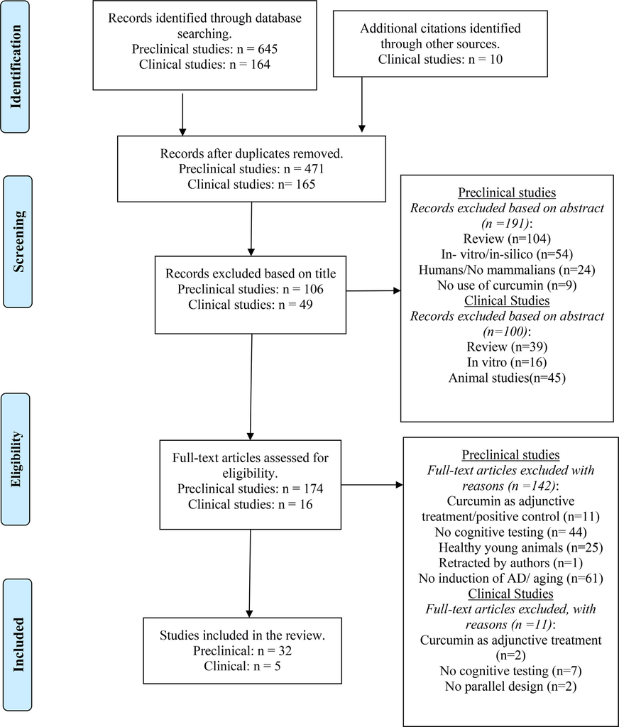

Fig. 1. Flow diagram of the systematic review process.

*Brain Research 1725 (2019) 146476*

3

Table 1

Summary of the included pre-clinical studies.

Study

Duration of

treatment

Study design, Dose & Route of administration

Species (N)

Cognitive

Measurements

Primary Objective

Main results

Alzheimer’s disease

Ishrat et al.

(2009)

3 weeks

(1) Sham:1operation + vehicle; (2) sham2:

operation + CUR (80 mg/kg, p.o); (3) STZ + vehicle, p.o;

(4) STZ + CUR (80 mg/kg, p.o)

Male Wistar rats (N = 40;

n = 10/group)

MWM, PA

The eﬀect of curcumin on cognitive

impairments and oxidative damage in

ICV-STZ infused rats.

CUR counteracted ICV-STZ-induced

alterations in cognitive and behavioral

parameters and in markers of oxidative

stress.

Agrawal et al.

(2010)

1–14 days (pre-

treatment)

14–20 days (post-

treatment)

(1) Untreated group; (2) swimming control (no training);

(3) vehicle treated group, p.o; (4) Sham group; (5) STZ

group; (6) pre-treated CUR (200 mg, p.o) + STZ; (7) post-

treated CUR 200 mg, p.o + STZ

Adult male

Sprague–Dawley rats

(N = 35; n = 5 per group)

MWM

The eﬀect of curcumin on memory

and insulin receptors in the brain.

Curcumin improved memory and

restored insulin, cholinergic and

oxidative stress markers.

Awasthi et al.

(2010)

1–21 days(pre-

treatment) 19–25

(post-treatment_

Pre-treatment: (1) Control group; (2) Sham group; (3) STZ

group; (4) STZ + 10 mg/kg CUR; (5) STZ + 20 mg/kg CUR;

(6) 50 mg/kg CUR, p.o. Post-treatment (1) STZ + vehicle;

(2) STZ + 25 mg/kg CUR; (3) STZ + 50 mg/kg CUR, p.o

Adult male Swiss albino

mice (n = 6–8 per group)

MWM, PA

The preventive and therapeutic eﬀect

of curcumin on memory, cerebral

blood ﬂow, oxidative stress and

cholinergic levels.

Curcumin prevented and reversed spatial

memory deﬁcits in a dose dependent

manner. Additionally, it improved

cerebral blood ﬂow, oxidative and

cholinergic levels in the brain.

Isik et al. (2009)

10 days

(1) Sham group; (2) STZ + vehicle (0.5 ml, i.p); (3)

STZ + CUR (300 mg/kg daily in vehicle, i.p)

Male Wistar rats (N = 24;

n1 = 8, n2 = 7, n3 = 8)

PA, MWM

The neuroprotective eﬀect of CUR

compared to ICV-STZ induced

cognitive impairments.

Curcumin signiﬁcantly improved

behavioral and histological alterations

resulting from ICV-STZ induction.

Additionally, IGF-1 levels were elevated

after administration of curcumin.

Samy et al.

(2016)

3 months

(1) Sham group; (2) ICV-STZ + vehicle; (3)

ICV-STZ + curcumin (80 mg/kg/day, p.o); (4)

ICV-STZ + erythropoietin (500 IU/kg qod, i.p); (5)

ICV-STZ + curcumin (80 mg/kg/day, p.o) & erythropoietin

erythropoietin (500 IU/kg qod, i.p)

Male Wistar rats (N = 40;

n = 8/group)

MWM, PA

The comparison of combined CUR

and erythropoietin treatment against

monotherapy in cognition.

Both combined and monotherapy

reversed cognitive, biochemical and

histological changes. However, curcumin

demonstrated a better safety proﬁle.

Bassani et al.

(2017)

30 days

(1) Sham group; (2) STZ infused group; (3) STZ + CUR

(25 mg/kg, p.o); (4) STZ + CUR (50 mg/kg, p.o); (5)

STZ + CUR (100 mg/kg, p.o)

Male Wistar rats (N = 35;

n1 = 7, n2 = 7, n3 = 6,

n4 = 8, n5 = 7)

OFT, OLT, ORT,

EPM, Y-Maze

To examine the possibility that

chronic administration of CUR may

favor cognition of STZ induced rats

and increase neuronal proliferation.

At high dosages curcumin might be able

to prevent short term recognition but not

spatial memory. No signs of neurogenesis

were evident, but reduced

neuroinﬂammation was observed.

Zhang et al.

(2015)

7 days

(1) Sham group; (2) Aβ1-42 + saline; (3) Aβ1-42 + 50, (4)

100, and (5) 200 mg/kg, i.p. of curcumin respectively

Male Sprague Dawley rats

(N = 40; n = 8 in each

group)

Y-Maze, OFT,

MWM

The modulating impact of curcumin

on cognitive deﬁcits after ventricular

injection of amyloid-β1-42 (Aβ1-42).

Chronic CUR supplementation attenuated

Aβ1-42 induced cognitive impairments

and increased BDNF levels in the

hippocampus.

Wang et al.

(2013)

7 days

(1) Sham group; (2) Aβ1–40 (10 μl) + vehicle (300 mg, i.p);

(3) Aβ1–40 + CUR (300 mg, i.p)

Male Sprague-Dawley rats

(N = 48; n = 16/group)

MWM

To examine the protective eﬀect of

CUR on Aβ1–40-induced cognitive

deﬁcits and explore whether CUR

acts on collapsing response mediator

protein-2 (CRMP-2).

Treatment with CUR signiﬁcantly

ameliorated cognitive impairments and

moderated phosphorylation of CRMP-2

leading to hippocampal regeneration.

Yin et al. (2014)

7 days

(1) Sham group; (2) Aβ1–40 + vehicle (300 mg/kg, i.p); (3)

Aβ1–40 + CUR (300 mg/kg, i.p)

Male Sprague-Dawley rats

(N = 48; n = 16/group)

MWM

To explore the underlying

mechanisms of curcumin for the

treatment of AD.

CUR signiﬁcantly improved spatial

memory performance. CUR’s mechanism

of action could be related with

suppressing hippocampal Nogo receptor

expression and subsequently increasing

axonal regeneration.

Frautschy et al.

(2001)

2 months

(1) Control group, vehicle; (2) Aβ infused + vehicle (chow);

(3) Aβ infused + CUR (500 ppm, chow)

Female Sprague-Dawley

rats (N = 30;

n = 10/group)

MWM

Protective activity of dietary

curcumin against Aβ-induced

neurotoxicity and cognitive deﬁcits.

CUR prevented memory deﬁcits and

attenuated Aβ deposits as well as post-

synaptic density (PSD)-95 loss.

Wang et al.

(2011)

7 days

(1) Sham group + saline; (2)Aβ1-40 + saline; (3)

Aβ1-40 + CUR (300 mg/kg/day, i.p)

Male Sprague-Dawley rats

(N = 48; n = 16/group)

MWM

The eﬀect of CUR on AD related

cognitive deﬁcits and cell apoptosis.

CUR signiﬁcantly improved cognitive

impairments and protected against

neuronal apoptosis.

(continued on next page)

*Brain Research 1725 (2019) 146476*

4

Table 1 (continued)

Study

Duration of

treatment

Study design, Dose & Route of administration

Species (N)

Cognitive

Measurements

Primary Objective

Main results

Wang et al.

(2014)

6 months

(1) APP/PS1 control group; (2) APP/PS1 + CUR (160 ppm);

(3) APP/PS1 + CUR (1000 ppm) in diet, chow

Male mice (N = 33;

n = 11/group)

MWM

To evaluate whether CUR can induce

autophagy and attenuate cognitive

impairments induced in APP/PS1

double transgenic mice model.

CUR improved memory in a dose

depended manner and induce autophagy.

Jia et al. (2016)

14 days

(1) CUR solution; (2) CUR-Pos; (3) CUR-Tf/-Pos (15 mg,

i.v); (4) CUR-Tet-1-Pos (15 mg, i.v); (5) CUR-Tf/Tet-1-Pos

(15 mg, i.v); (6) Aβ1-42 induced control group + saline i.v;

(7) sham control group

Male C57BL/6 mice (n = 8

per group)

MWM

The eﬀect of diﬀerent formulations of

CUR on cognition in Aβ1-42 induced

mice.

CUR-Tf/Tet-1-Pos and CUR-Tf-PO

formulations demonstrated signiﬁcant

improvement after Aβ-induced memory

and cognitive impairment. In vivo and in

vitro results supported better

bioavailability of Tf/Tet-1-Pos

formulation.

Hoppe et al.

(2013)

10 days

(1) Sham group; (2) sham + free CUR; (3)

sham + CUR-loaded lipid-core nanocapsules (Cur-LNC

group); (4) Aβ1-42 infused group; (5) Aβ1-42

infused + vehicle (6) Aβ1-42 infused + blank lipid-core

nanocapsules (B-LNC group), (7) i.c.v infused + free CUR;

(8) Cur-LNC group) → 50 mg/kg/day CUR and 2.5 mg/kg/

day Cur-LNC, i.p.

Male Wistar rats

(n = 10–16/ group)

Y-Maze, NORT

To compare eﬃcacy and

bioavailability of free CUR versus

Cur-LNC and identify potential

mechanisms underlying curcumin’s

protection against Aβ (1 −4 2) induced

cognitive impairment.

Administration of curcumin in both

formulations prevented behavioral

impairments, neuroinﬂammation, as well

as cell synaptic malfunctions triggered by

Aβ induction. Nanoencapsuled curcumin

demonstrated higher potency compared

to free CUR.

Tiwari et al.

(2013)

3 weeks

(1) Sham group; (2) Aβ untreated (2) Aβ + empty PLGA-

NP-; (3), (4) Aβ + bulk Curcumin-Treated Group (0.5 and

20 mg/kg, i.p.) mg/kg); (5), (6) CUR-PLGA-NPs-Treated

Group (0.5 and 20 mg/kg, i.p.)

Male Wistar rats

(n = 6/group)

PA

Comparison between bulk CUR and

CUR nanoparticles in hippocampal

neurogenesis and cognition.

CUR-loaded nanoparticles at both doses

and high dose of bulk curcumin

ameliorate cognitive impairments and

potentially increases neurogenesis in an

Aβ rat model.

Ahmed et al.

(2010)

5 days → short term

& 20 days → long

term

(1) Control group; (2) Ab induced group; (3), (4)

curcuminoids 3 mg/kg and 30 mg/kg, i.p; (5), (6) curcumin,

3 mg/kg and 30 mg/kg, i.p; (7), (8) bisdemethoxycurcumin

3 mg/kg and 30 mg/kg, i.p; (9), (10) demethoxycurcumin

3 mg/kg and 30 mg/kg, i.p

Male, Sprague–Dawley

rats (n = 8/group)

MWM

The eﬀects of curcuminoid mixture

and its individual constituents on

spatial learning and memory in an

amyloid-beta (Αβ) peptide-infused

rat model of AD.

Individual curcuminoid components

demonstrate more eﬀective proﬁle than

the parent mixture on memory

performance.

Ma et al. (2013)

4 months

(1) Wild-type animals; (2) Control hTau mice; (3)

hTau + CUR -Longvida (500 ppm in chow)

Male & female C57Bl/6J

mice (N = 24; n1 = 9,

n2 = 7, n3 = 8)

MWM, Y-Maze,

NORT

The eﬀect of dietary curcumin on

NFTs accumulation and memory.

CUR supplementation enhanced cognitive

performance in mice and reduced soluble

tau aggregates.

Sundaram et al.

(2017)

12 weeks

(1) WT normally fed; (2) WT Longvida 4 g/kg (0.8 g CUR/

kg) in chow; (3) p25Tg normally fed; (4) p25Tg CUR

Longvida 4 g/kg (0.8 g CUR/kg) in chow

Male & female C57BL/6

mice (N = 22; n1 = 5,

n2 = 6, n3 = 5, n4 = 6)

8-arm radial maze

To investigate fundamental and

behavioral eﬀects of Longvida® on

AD mice model.

Dietary Longvida improved cognitive

functions and mitigated

neuroinﬂammation as well as features of

AD.

Yanagisawa

et al. (2015)

6 months

(1) WT group; (2) Control group, APPswe/PS1dE9; (3)

APPswe/PS1dE9 + free CUR; (4)

APPswe/PS1dE9 + FmeC1; (5)

APPswe/PS1dE9 + FmeC2 → 500 ppm in chow

Male & female C57BL/6

mice (N = 48; n1 = 12,

n2 = 12, n3 = 6, n4 = 12,

n5 = 6)

MWM, Y-Maze

To compare free CUR, FmeC1 and

FmeC2 for the treatment of AD.

FmeC1 showed superior eﬃcacy in

reducing cognitive deﬁcits and Aβ

aggregates compared to the other two

formulations.

Okuda et al.

(2017)

9 weeks

(1) SAMP8/TaSlc + vehicle; (2) SAMP8/TaSlc + PE859

(1 mg/kg/day, i.g); (3) SAMP8/TaSlc + PE859 (3 mg/kg/

day, i.g)

Male SAMP8/TaSlc mice

(N = 25; n1 = 9,

n2 = n3 = 8)

MWM, Y-Maze,

Rotarod, Grip

strength

To examine the eﬃcacy of a new CUR

derivative, named PE859 on an AD

model.

Even though no signiﬁcant diﬀerences

were observed in behavioral testing,

PE859 reduced Aβ1-40 aggregates.

McClure et al.

(2017)

18 Weeks

(1) WT group; (2) 5XFAD, control; (3) 5XFAD + 5 mg/kg

CUR, i.n

Male & female C57BL/6

mice (N = 30;

n = 10/group)

Y-maze

To evaluate intranasal formulation of

CUR for the prevention of AD.

Nebulized CUR prevented memory

deﬁcits and reduce formation of Aβ

plaques.

Ageing

Kumar et al.

(2011)

6 weeks

(1) Vehicle control group; (2) D-gal (100 mg/kg, s.c.); (3)

Galantamine (5 mg/kg, p.o.) + d-gal (100 mg/kg); (4) CUR

(15 mg/kg, p.o.) + d-gal (100 mg/kg); (5) CUR (30 mg/kg,

p.o) + d-gal (100 mg/kg, s.c); (6) CUR alone (30 mg/kg,

p.o)

Male Laca mice (n = 12

per group)

MWM, EPM

To explore the possible protective

role of curcumin against D-galactose-

induced cognitive dysfunction,

oxidative damage, and mitochondrial

dysfunction in ageing mice.

All treatment groups showed

improvement in cognitive and

neurobiochemical markers. Locomotor

ability remained unchanged.

(continued on next page)

*Brain Research 1725 (2019) 146476*

5

Table 1 (continued)

Study

Duration of

treatment

Study design, Dose & Route of administration

Species (N)

Cognitive

Measurements

Primary Objective

Main results

Nam et al.

(2014)

10 weeks

(1) Control group + vehicle; (2) D-gal (100 mg/kg, s.c); (3)

CUR (300 mg/kg, p.o) (4) D-gal (100 mg/kg, s.c) + CUR

(300 mg/kg, p.o)

Male C57BL/6 mice

(n = 10 per group)

MWM

The eﬀects of CUR on learning and

spatial memory in healthy and D-

galactose-induced aged mice.

Curcumin protected against memory

impairment induced by D-gal and

increased neurogenesis in the

hippocampus.

Banji et al.

(2013a,b)

49 days

(1) Young rats + vehicle, p.o; (2) Aged rats + vehicle, p.o;

(3) Young rats + D-gal (60 mg/kg, i.p); (4) Young

rats + D-gal + CUR (20 mg/kg, p.o); (5) Young

rats + D-gal + piperine (6 mg/kg, p.o); (6) Young

rats + D-gal + CUR (20 mg/kg, p.o) + piperine (6 mg/kg,

p.o); (7) Young rats + D-gal + CUR (40 mg/kg,

p.o) + piperine (12 mg/kg, p.o)

Male Wistar rats (N = 36;

n = 6 per group)

MWM

To compare eﬀects of single and

combined administration of CUR and

piperine on aging.

Superior eﬀect of combined compared to

separate administration of CUR and

piperine in cognitive and

neurobiochemical changes related to

aging.

Banji et al.

(2013a,b)

56 days

(1) Young rats + vehicle, p.o; (2) Aged rats + vehicle, p.o;

(3) Young rats + D-gal (150 mg/kg, s.c); (4) Young

rats + D-gal + CUR (40 mg/kg, p.o); (5) Young

rats + D-gal + piperine (7.5 mg/kg, p.o); (6) Young

rats + D-gal + CUR (20 mg/kg, p.o) + piperine (7.5 mg/

kg, p.o); (7) Young rats + D-gal + CUR (40 mg/kg,

p.o) + piperine (15 mg/kg, p.o)

Male Wistar rats (N = 36;

n = 6 per group)

EPM, Rotarod

To delineate the synergistic eﬀect of

curcumin and piperine in treating

aging symptoms and to compare it

with monotherapy.

Co-administration of CUR and piperine

improved cognitive and motor D-gal

induced impairment and reduced

oxidative stress.

Banji et al.

(2014)

63 days

(1) Control group + vehicle; (2) D-gal (150 mg/kg,

s.c) + vehicle; (3) D-gal + CUR (50 mg/kg, p.o); (4)

D-gal + hesperidin (10 mg/kg, p.o); (5) D-gal + CUR

(50 mg/kg, p.o) + hesperidin (10 mg/kg, p.o); (6)

D-gal + CUR (100 mg/kg, p.o) + hesperidin (25 mg/kg,

p.o)

Wistar rats (Not

mentioned)

MWM

To delineate the combination of CUR

and hesperidin as compared to their

individual administration for the

treatment of D-gal induced cognitive

impairments.

The mixture of CUR and hesperidin as

well as individual administration

minimized the behavioral impairments.

The higher doses of the mixture reversed

apoptosis, mitochondrial and oxidative

damage.

Sun et al. (2013)

25 Days

(1) SAMR1 mice, as control (normal aging); (2) SAMP8

mice; (3) SAMP8 + CUR (20 mg/kg, i.g); (4) SAMP8 + CUR

(50 mg/kg, i.g)

Male SAMP8 and

SAMR1 mice

(n = 22/group)

MWM

The eﬀect of CUR on learning and

memory in aging and its possible

mechanisms.

Both dosages of CUR signiﬁcantly

improved cognition, normalized

oxidative damage and enhanced synaptic

plasticity. The higher dose displayed

stronger eﬀects.

Dong et al.

(2012)

6 &12 weeks

(1) Control group; (2) CUR (480 mg/kg, in chow) → six

weeks; (3) CUR (480 mg/kg, in chow) → twelve weeks

Male Sprague-Dawley rats

(N = 45; n = 15/group)

OFT, Rotarod,

social recognition

test, MWM

To assess behavioral performance and

hippocampal cell proliferation in

aged rats after 6- and 12-week

curcumin-fortiﬁed diets.

Non spatial memory improved at both

durations, whereas spatial memory was

improved after long-term treatment but

not after short-term. Increased

neurogenesis after 12-week treatment.

Belviranlı et al.

(2013)

12 days

(1) Aged control group + vehicle; (2) Aged Cur group

(300 mg/kg/day, p.o)

Female Wistar rats

(N = 20; n = 10/group)

MWM

The eﬀect of CUR on cognitive

impairments and oxidative stress

induced by age.

Administration of CUR signiﬁcantly

improved spatial learning and memory,

whereas some markers of oxidative stress

were decreased.

Yu et al. (2013)

21 days

(1) Young control group + vehicle; (2) Aged control

group + vehicle; (3) Aged CUR group (50 mg/kg, i.p); (4)

Aged CUR (50 mg/kg, i.p) + 7-NI (150 mg/kg, i.p); (5)

Aged 7-NI (150 mg/kg, i.p)

Male Kunming mice

(N = 48; n = 12/group)

NORT, PA

To investigate the eﬀect of CUR on

cognitive decline caused by aging and

to explore its mechanism of action.

CUR alleviated memory impairment in

aged mice.

Vidal et al.

(2017)

60 days

(1) Aged control group + vehicle; (2) Aged CUR treated

group (100 mg/kg/day, p.o)

Male Sprague‐Dawley rats

(N = 20; n = 20 per

group)

NORT

To investigate the eﬀects of curcumin

treatment in aged rats and its relation

with neurogenesis.

CUR improved memory and elevated

dendritic spine density and length in

certain brain regions.

Moore et al.

(2017)

8 months

(1) Middle aged control group + vehicle; (2) Middle aged

CUR treated group (500 mg in diet)

Male & female rhesus

monkeys, Macaca mulatta,

(N = 17; n1 = 9, n2 = 8)

DNMS, DRST

The eﬀect of CUR on aging related

memory deﬁcits.

CUR improved spatial but not recognition

memory in middle aged monkeys.

CUR = curcumin, i.p. = intraperitoneal, p.o. = per os (orally), i.g. = intragastrical, s.c. = subcutaneous injection, i.v. = intravenous, i.n. = intranasal, ICV = intracerebroventricular, WT = wild type, MWM = Morris

Water Maze, PA = passive avoidance task, OFT = open ﬁeld test, OLT = Object location test, ORT = object recognition test, NORT = Novel Object Recognition task, EPM = elevated plus maze, DNMS = delayed non-

matching to sample task, DRST = delayed recognition span task, SAMP8 = senescence-accelerated mouse prone 8, SAMR1 = senescence-accelerated-resistant, qod = every alternate day, KI = knock-in, 3NP = 3-

nitropropionic acid, C-SLN = curcumin solid lipid nanoparticle

*Brain Research 1725 (2019) 146476*

6

promotes phosphorylation of tau protein was upregulated and neuronal

loss was mitigated after treatment with curcumin.

More recently, Samy et al. (2016) studied the role of curcumin as

well as erythropoietin in an ICV-STZ rat model. Animals were injected

with saline or STZ. The latter group was treated subsequently with

vehicle, curcumin (80 mg/kg/day, p.o), erythropoietin (500 IU/kg

every other day, i.p) or with a combination of curcumin and ery-

thropoietin for three months. Administration of curcumin and/or ery-

thropoietin restored behavioral, histological and biochemical ICV-

STZ induced alterations. However, curcumin was considered preferable

due to its less severe long-term adverse eﬀects compared to ery-

thropoietin.

Contrary, a study evaluating prolonged administration of oral cur-

cumin at doses of 25, 50 and 100 mg/kg, found no beneﬁcial eﬀect in

short-term spatial memory of ICV-STZ infused rats (Bassani et al.,

2017). However, an improvement was detected in short term recogni-

tion memory. Additionally, even though curcumin did not increase

neurogenesis, a reduction of neuroinﬂammatory biomarkers was ob-

served, which according to authors could possibly contribute to the

frequently observed therapeutic eﬀects of curcumin.

The familial form of AD (FAD) was studied by Zhang et al. (2015),

who evaluated the protective eﬀect of curcumin at 50, 100, and

200 mg/kg, i.p on intraventricularly injected Aβ1-42 animals. Acute

treatment with curcumin did not exert positive results. However, cog-

nitive deﬁcits, shown at the Y-maze and MWM, improved after chronic

treatment (7-day administration) with 200 mg/kg curcumin compared

to placebo. The results were comparable to the sham group. Similarly,

Wang et al. (2013) and Yin et al. (2014) tested the eﬀect of curcumin

(300 mg/kg, i.p) on a Aβ1–40 AD model and found that curcumin re-

versed spatial learning and memory impairments concomitantly pro-

moting hippocampal regeneration.

Frautschy et al. (2001) tested whether dietary curcumin has a

protective eﬀect on Aβ-induced neurotoxicity when administered for

2 months prior to Aβ1-42 and Aβ/HDL injection. A dose of 500 ppm of

curcumin reversed spatial memory impairments as compared to the

untreated Aβ-infused rats. Additionally, curcumin protected against Aβ

deposits to a greater extent than ibuprofen. Another group evaluated

curcumin (300 mg/kg, i.p) on a Aβ1-40 model (Wang et al., 2011).

Curcumin improved spatial memory to levels comparable to the sham

group and suppressed neuronal apoptosis in the hippocampus by bal-

ancing the expression of the two apoptotic genes, Bax and Bcl-2.

The eﬀect of diﬀerent doses of curcumin was explored by Wang

et al. (2014). This group utilized an APP/PS1 double transgenic AD

model to examine the eﬀect of low (160 ppm) and high (1000 ppm)

dose of curcumin after administration for 6 months in diet. The re-

searchers detected a signiﬁcant cognitive improvement at both doses

compared to the untreated group, while a signiﬁcant dose-response

eﬀect was found throughout time with higher doses of curcumin pro-

ducing greater cognitive improvement. In addition, data suggest that

curcumin reduced Aβ deposits potentially by promoting autophagy.

3.1.1.2. Formulated curcumin. Despite the positive eﬀects of curcumin

on cognition, its main disadvantages when administered to a human

organism

are

the

low

bioavailability,

the

rapid

gastrointestinal

metabolism and the poor blood brain barrier (BBB) penetration.

Therefore, many formulations aiming to improve the bioavailability

and

stability

of

curcumin

have

been

developed.

One

of

these

formulations includes polymersomes (POs) loaded with curcumin,

accompanied by transferrin (Tf) and Tet-1 peptide (Tf/Tet-1-POs) (Jia

et al., 2016). POs are artiﬁcial vesicles in which the drug is loaded to

control permeability and increase stability. In addition, Tf is used to

increase BBB permeability via endocytosis and Tet to facilitate the

delivery to neurons due to its aﬃnity with the ganglioside GT1B

receptor on neurons. In the study by Jia et al. (2016), Aβ1-42 AD mice

were treated with curcumin (15 mg/kg, i.v) for 14 consecutive days to

test diﬀerent combinations of the abovementioned constituents. Results

illustrated a signiﬁcant improvement of Aβ-induced spatial and

learning memory in mice treated with curcumin-Tf/Tet-1-PO and

curcumin-Tf-PO compared with the untreated controls. The fact that

animals

treated

with

the

empty

Tf/Tet-1-PO

did

not

display

improvement in their performance suggests that curcumin is the

compound contributing to the beneﬁcial outcome.

Another formulation of curcumin was evaluated by Hoppe et al,

who tested the diﬀerential eﬀects of free curcumin and curcumin-

loaded lipid-core nanocapsules (Cur-LNC) for 10 days in an Aβ1-42-in-

duced model (Hoppe et al., 2013). The results showed signiﬁcant im-

provement in cognitive tests for both formulations of curcumin. Inter-

estingly, a 20-fold lower dose of Cur-LNC (2.5 mg/kg/day, i.p)

demonstrated similar neuroprotective eﬀects as the high dose free

curcumin (50 mg/kg/day). Furthermore, downregulated levels of the

proinﬂammatory cytokines TNF-α and IL-1β in the hippocampus were

observed only after administration of Cur-NLC, indicating higher bio-

distribution of curcumin under nanoparticle formulation.

Tiwari et al. (2013) reported comparable results. Curcumin-loaded

biodegradable poly (lactic-co-glycolic acid) (PLGA) nanoparticles (Cur-

PLGA-NPs) were found to be eﬀective in reversing cognitive impair-

ment and increasing neurogenesis in an AD rat model at a lower dose

Cur-PLGA-NPs, a 2.1- and 2.8-fold respective increase was reported in

brain curcumin levels compared to the same doses of natural curcumin,

indicating increased bioavailability of this formulation.

Ahmed et al. (2010) compared the eﬀects of the parent curcuminoid

mixture with its three separate constituents, speciﬁcally curcumin,

bisdemethoxycurcumin and demethoxycurcumin in Aβ-infused rats. All

components showed a memory-enhancing eﬀect at 3 mg/kg, i.p,

whereas the curcuminoid mixture had no eﬀect on memory at the same

dose. At 30 mg/kg, i.p all treated groups showed a signiﬁcant beneﬁcial

eﬀect on memory, but the three separate components showed addi-

tional improvement over time, suggesting that the parent curcuminoid

mixture might not be as eﬀective as its separate components. On a

molecular level, after short term treatment the curcuminoid mixture

and the bisdemethoxycurcumin improved post-synaptic density protein

(PSD-95) in the hippocampus, a marker of postsynaptic plasticity, with

the lower dose (3 mg/kg) being more eﬀective. However, after pro-

longed administration the other two components show similar out-

come. Interestingly, after long term treatment a high dose of de-

methoxycurcumin

(30 mg/kg)

seemed

to

be

more

eﬀective

in

augmenting synaptophysin and calcium/calmodulin dependent protein

kinase type IV (camkIV) expression - biomarkers of synaptic plasticity -

compared to the other compounds. The authors suggested that these

results probably indicate that diﬀerent compound compositions could

result in diﬀerent beneﬁcial outcomes depending on the model or the

type of the disease.

Yanagisawa et al. (2015) utilized the double transgenic APP/PS1

model to compare three forms of dietary curcumin; natural curcumin,

FMeC1 and FMeC2. FMeC1 is a derivative of curcumin substituted at

the C-4 position, which previously has shown to bind to Aβ deposits,

while leaving Aβ monomers untouched (Yanagisawa et al., 2010).

FMeC2 is a product of FMeC1 hydrolysis. Improved spatial memory

comparable to the sham group, was evident in the group treated with

FMeC1; however, no memory improvement was observed in the group

treated with free curcumin or FMeC2. Likewise, treatment with FMeC1

reduced the accruement of Aβ40 and Aβ42, while this trend was not

observed after treatment with natural curcumin or FMeC2. Ad-

ditionally, Okuda et al. (2017) evaluated a new derivative of curcumin,

called PE859 (1 and 3 mg/kg/day, i.g), on a SAMP8/TaSlc mouse

strain. No signiﬁcant diﬀerences were displayed on spatial learning and

memory. However, PE859 seemed to diminish insoluble Aβ1-40 but not

Aβ1-42 deposits.

Besides Aβ deposits NFT’s accumulation is a hallmark of AD. For

that reason, Ma et al. (2013) explored the eﬀect of dietary solid lipid

*Brain Research 1725 (2019) 146476*

7

nanoparticle Longvida® (500 ppm) on a Tau mice model with in-

traventricular injections of tau dimers. Their ﬁndings suggest that

curcumin supplementation may improve memory and result in a

number of biochemical alternations leading to suppressed tau ag-

gregation. To examine abnormal deposition of both Aβ and NFT’s,

Sundaram et al. (2017) chose to use a p25 transgenic mice model to

evaluate the same dietary form of curcumin. Both features of AD were

reduced presumably due to suppressed levels neuroinﬂammatory cy-

tokines MIP-1α, TNF-α and IL-1β. Additionally, Longvida® improved

spatial and working memory as observed in the 8-arm radial maze.

More recently, McClure and his team (2017) introduced an inhaled

formulation of curcumin to increase BBB permeability and tested its

eﬃcacy in preventing AD. They have shown that treating young 5XFAD

mice with intranasal curcumin prevented memory deﬁcits and Aβ

plaque burden in adulthood as compared to the untreated mice. In

addition, no side eﬀects or incidents of toxicity were reported in the

respiratory and the circulatory system of the animals as expected to due

to the nebulized form of curcumin.

Overall, the vast majority of AD animal models indicates that cur-

cumin has both preventive and therapeutic eﬀects on cognition.

Beneﬁcial eﬀects are observed not only on molecular but also on be-

havioral level. Formulated curcumin seems to result in increased

bioavailability compared to the natural compound.

3.1.2. Non-pathological ageing

Aging is a physiological process associated with functional, mor-

phological and biochemical alternations in the central and peripheral

nervous system. The biological underpinnings of aging remain unclear;

however, oxidative stress, inﬂammation and mitochondrial dysfunction

have been suggested to play an important role in age-related cognitive

impairments, causing individuals to become vulnerable for developing

neurodegenerative diseases (Troen, 2003). Given its potential positive

eﬀects on oxidative stress and inﬂammation, curcumin could be of in-

terest in ameliorating aging-associated cognitive impairments and/or

reducing the risk for development of neurodegenerative diseases, such

as AD.

Kumar et al. (2011) studied the neuroprotective eﬀects of orally

administered curcumin at 15 and 30 mg/kg using galantamine (5 mg/

kg) -an acetylcholinesterase inhibitor prescribed for the treatment of

cognitive decline in AD- as a positive control group in a D-galactose (D-

gal) animal model. D-gal is a decreasing sugar that can accelerate se-

nescence and induce cognitive dysfunction to experimental animals in a

way that resembles human aging. Groups treated either with curcumin

or galantamine performed better on cognitive tasks compared to the

untreated D-gal group, even though locomotor activity remained the

same in all groups. In addition, both curcumin and galantamine di-

minished levels of oxidative stress and mitochondrial dysfunction. The

results thus indicate that CUR could be an alternative treatment for

aging-induced cognitive deﬁcits with a higher dose showing more

beneﬁcial results.

Equally, Nam et al. (2014) studied the eﬀects of orally administered

curcumin at 300 mg/kg in D-gal induced mice. A beneﬁcial trend of

curcumin on learning and spatial memory was observed in D-gal mice

treated with curcumin as compared to the vehicle treated D-gal mice.

No signiﬁcant diﬀerence was found in cognitive performance between

curcumin and vehicle treated healthy animals. Results demonstrated

increased neuronal proliferation in the hippocampus after administra-

tion of curcumin, as evident by the elevated brain-derived neurotrophic

factor (BDNF) protein expression and increased phosphorylation of the

transcription factor CREB in the respective brain region.

The same model was applied to compare the synergistic eﬀect of

curcumin and piperine versus curcumin and piperine monotherapy

when administered orally at doses of 20 mg/kg or 40 mg/kg for cur-

cumin and 6 mg/kg or 12 mg/kg for piperine by the group of Banji et al.

(2013a,b). Combined curcumin and piperine showed superiority, in a

dose dependent manner, compared to separate administration in

ameliorating memory and normalizing oxidative burden, biochemical

levels and hippocampal morphology. Moreover, using a similar study

design they compared the same compound synergism but this time

using higher doses of piperine (Banji et al., 2013a,b). As in the previous

study, co-administration of curcumin and piperine ameliorated move-

ment and cognitive deﬁcits caused by D-gal administration, while also

reducing oxidative stress in a dose dependent manner. One year later

the same group evaluated the eﬀects of combined curcumin and he-

speridin (glycoside). Likewise, both separate and co-administration

augmented behavioral performance with higher doses of the mixture

demonstrating better overall proﬁle in reducing mitochondrial and

oxidative damage as well as apoptosis (Banji et al., 2014).

Sun et al. (2013) studied the eﬀects of 20 and 50 mg/kg curcumin

when administered intragastrically using senescence-accelerated mouse

prone 8 (SAMP8 mice). SAMP8 is a line that closely mimics human’s

phenotype of senescence; therefore, it was compared with a normal

aging SAMR1 strain. They found an improvement in spatial memory at

both doses of curcumin compared to the untreated SAMP8 mice as well

as enhanced antioxidant capacity and synaptic plasticity. Again,

stronger eﬀects were found on the high dose of curcumin (50 mg/kg).

A diﬀerent approach was followed by Dong et al., who instead of

modeling senescence in young animals, evaluated the eﬀect of cur-

cumin in normal aging rats (Dong et al., 2012). Non-spatial and spatial

memory were tested after 6 and 12 weeks of curcumin treatment

(480 mg/kg in chow). After 12-weeks curcumin treatment, spatial

memory signiﬁcantly improved in the aged rats, whereas no eﬀect was

found after a 6-week administration. A subtle improvement in non-

spatial memory was detected in the curcumin group after both treat-

ment durations. Interestingly, increased neurogenesis was observed in

the hippocampus of the rats after prolonged administration of cur-

cumin.

Another study found small beneﬁcial eﬀects of curcumin (300 mg/

kg/day, p.o) in aged rats (Belviranlı et al., 2013). Performance on

learning and spatial memory improved in curcumin treated compared

to vehicle treated rats. However, except from a downregulated marker

of oxidative stress (malondialdeyde) in the group treated with curcumin

of curcumin on aged rats (Yu et al., 2013). Curcumin ameliorated

cognitive deﬁcits induced by aging. The underlying mechanism of

curcumin’s action could be attributed to the activation of the neuronal

nitric oxide synthase/nitric oxide (nNOS/NO) pathway.

In a more recent study, Vidal et al. (2017) similarly examined the

eﬀect of oral curcumin on aged rodents. Animals treated with curcumin

exhibited better performance on recognition memory as compared to

the vehicle treated group. Additionally, curcumin improved dendritic

spike density and dendritic length in the hippocampus and the pre-

frontal cortex, however, with regards to the amygdala the results were

not consistent across measurements.

The only study examining non-human primates was the study of

Moore et al. (2017). In this study middle aged rhesus monkeys received

curcumin or placebo in their diet to assess its eﬀect on age related

cognitive deﬁcits. Results revealed amelioration of spatial memory in

the curcumin treated animals, however, no improvement was observed

concerning the visual recognition memory. According to the authors,

this deviation could probably be explained by the fact that in middle

aged monkeys recognition memory has not begun to decline yet,

whereas spatial memory is typically deteriorated at this age-range.

In general, results indicate that curcumin may beneﬁt age-related

cognitive impairments. Higher doses of curcumin seem to be more ef-

fective compared to the lower doses regardless the route of adminis-

tration and co-administration with piperine seems to enhance further

curcumin’s eﬀect.

*Brain Research 1725 (2019) 146476*

8

Table 2

Summary of the included human studies.

Study

Study Design

Study design & Dose

Duration

Disorder Age (N)

Cognitive

Measurements

Primary Objective

Main results

AE

Rainey-Smith

et al.

(2016)

R, DB, PC, PG

(1) Placebo (2) 1500 mg/

day BiocurcumaxTM

12 months

Healthy elderly

40–90 y (N = 96;

n1 = 57, n2 = 39)

(1) RAVLT (2) COWAT;

(3) WAIS-R; (4)

Computerised CogState

battery; (5) MoCA

Ability of curcumin to

prevent cognitive decline

Cognitive decline after 6 months in

placebo but not in curcumin. Eﬀect on

mood

23 gastrointestinal complains (2 on

placebo)

Cox et al.

(2015)

R, DB, PC, PG

(1) Placebo; (2) 400 mg

Longvida® (assessment: 1

and 3 h and 4-week

treatment)

4 weeks

Healthy elderly

60–85 y (N = 60;

n1 = 30, n2 = 30)

(1) COMPASS; (2)

DASS21; (3) CFS; (4)

BL-VAS; (5) STAI

Eﬀect of acute and chronic

administration of curcumin

on cognition, mood and

biochemical. measures

Single-dose improved performance on

working memory and sustained

attention. Four-week treatment

improved WM and reduced fatigue.

Downregulation in total and LDL

cholesterol.

NO

Baum et al.

(2008)

R, DB, PC, PG

(1) Placebo; (2) CUR (1 g);

(3) CUR (4 g) → CUR was

given either as powder or

in capsules

6 months

Cognitive decline/

possible AD > 50

(N = 27; n1 = 8,

n2 = 8, n3 = 11)

MMSE

Safety, biochemical and

cognitive changes in AD

No diﬀerences on cognitive decline

were observed. Similar bioavailability

between 1 and 4 g CUR, but better

bioavailability when CUR administered

in capsules

4 gastrointestinal (2 on placebo, 2 on

1 g, 1 on 4 g), 3 respiratory tract

infections (2 on placebo, 1 on 1 g), 3

dizziness (1 on placebo, 1 on 1 g, 1 on

4 g), 2 delusions (1 on 1 g, 1 on 4 g), 2

edema (1 on placebo, 1 on 1 g), 1

hearing impairment (on placebo)

Ringman

et al.,

(2012)

R, DB, PC, PG

(Open label

extension)

(1) Placebo; (2) Curcumin

C3 Complex ® (2 g/day);

(3) Curcumin C3 Complex

® (4 g/day)

24 weeks

(48 weeks- open

label extension)

Mild-to-moderate

AD > 49

(N = 30; n1 = 10,

n2 = 10, n3 = 10)

(1) (ADAS-Cog); (2)

NPI; (3) ADCS-ADL

Safety and tolerability of

Curcumin C3 Complex ®.

Eﬃcacy in cognition

Non-signiﬁcant change on MMSE

results after Curcumin C3 Complex ®

administration. Low bioavailability of

the compound and no alternations of

AD biomarkers

Three gastrointestinal symptoms

Small et al.,

(2018)

R, DB, PC, PG

(1) Placebo; (2)

Theracurmin® (90 mg

CUR) orally, b.i.d

18 months

Non-demented

51–84 y (N = 40;

n1 = 19, n2 = 21)

(1) SRT; (2) BVMT-R;

(3) Trail Making Test

The eﬀect of curcumin on

memory performance and

on deposition of amyloid

plaques and tau tangles

Theracurmin® improved memory and

attention performance and prevented

neuropathological deposition in

amygdala and hypothalamus

Gastrointestinal complain (4 in the

curcumin and 2 in the placebo group)

R = randomized, DB = double blind, PC = placebo control, PG = parallel groups, WM = working memory, RAVLT = Rey Auditory Verbal Learning Test, COWAT = Controlled Oral Word Association Test, WAIS-

R = Wechsler Digit Symbol Scale from the Wechsler Adult Intelligence Scale revised, MoCA = Montreal cognitive assessment, COMPASS = Computerized Mental Performance Assessment System, DASS21 = 21-item

version of the Depression, Anxiety and Stress Scales, CSF = Chalder Fatigue Scale, BL- VAS = Bond-Lader Visual Analogue Scales, STAI = State-Trait Anxiety Inventory, MMSE = Mini- Mental State Examination, ADAS-

Cog = Alzheimer's Disease Assessment Scale - Cognitive Subscale, NPI = Neuropsychiatric Inventory, ADCS-ADL = Alzheimer's Disease Cooperative Study - Activities of Daily Living, NPI-Q = Neuropsychiatric in-

ventory-brief questionnaire, b.i.d = bis in die, SRT = Buschke Selective Reminding Test, BVMT-R = Brief Visual Memory Test-Revised.

S.D. Voulgaropoulou, et al.

*Brain Research 1725 (2019) 146476*

9

3.2. Clinical trials

With regards to human data, a few randomized clinical trials (RCTs)

have been conducted measuring cognitive functioning after curcumi-

noid administration. The majority of these trials included an elderly

population, with or without AD. In total ﬁve articles met the inclusion

criteria. Study speciﬁcs are displayed in Table 2.

Rainey-Smith et al. (2016) conducted a randomized study in which

participants between 40 and 90 years old without cognitive impairment

were tested on a battery of clinical and cognitive testing after

12 months of 1500 mg Biocurcumax™ or placebo administration. The

results showed cognitive decline after 6 months in the placebo group on

the Montreal cognitive assessment, that is used to assess general cog-

nitive functioning; however, cognitive performance in the curcumin

group remained stable. This diﬀerence on Montreal cognitive assess-

ment was not observed after the 12-month follow-up. Other cognitive

and clinical measures revealed no diﬀerences between groups across

time. The authors concluded that curcumin does not enhance cognition,

but rather attenuates its decline over time. It must be noted that out of

160 participants that underwent baseline assessment, 23 subjects, two

of which belonged in the placebo group, were excluded from the ana-

lysis due to reported gastrointestinal complains, suggesting that the

high dose of Biocurcumax™ used in the study has probably impacted

tolerability of the compound.

A comparable population was assessed by Cox et al. (2015). Sixty

healthy adults, between 65 and 80 years of age, were tested using an

acute (1 and 3 h after a single dose), chronic (four weeks) and acute-on-

chronic (1 and 3 h after single dose following 4-week treatment) ad-

ministration of 400 mg dose of Longvida® Optimized Curcumin. This

compound is a solid lipid formulation that contains approximately

80 mg of curcumin. One-hour post-dose, curcumin administration had a

beneﬁcial eﬀect on working memory and sustained attention mea-

surements. A similar pattern was observed after chronic administration;

however, no signiﬁcant results were found 3 h post-acute administra-

tion. Moreover, mood was improved; increased calmness and a reduc-

tion in fatigue were observed in the chronic curcumin group.

Examining the eﬀect of curcumin on cognition, Baum et al. (2008)

conducted a pilot trial in a Chinese adult population, over 50 years of

age with progressive cognitive impairment (probable or possible AD).

Curcumin was administered at 1 or 4 g either in capsules or as powder

for 6 months and was compared to placebo. No diﬀerences in Mini-

Mental state examination (MMSE) scores were detected throughout

time or among treatments. Additionally, there was no signiﬁcant dif-

ference in serum Aβ1-40 levels among treatments, however Aβ1-40 levels

tended to increase on curcumin, indicating reduced Aβ aggregation in

the brain after treatment with curcumin. Additionally, curcumin in-

creased vitamin E, reﬂecting a potential antioxidant activity. Interest-

ingly, capsules exhibited better bioavailability compared to the powder

formulation, whereas no diﬀerences in curcumin’s metabolites was

observed between 1 and 4 g. Furthermore, no severe side eﬀects were

reported after curcumin’s administration.

Ringman et al. (2012) evaluated the eﬃcacy of a diﬀerent curcumin

formulation; the Curcumin 3 Complex®, which is the parent curcumi-

noid mixture comprising the three diﬀerent constituents (curcumin,

bisdemethoxycurcumin and demethoxycurcumin). The compound was

administered for 24 weeks in a population with mild to moderate AD.

Participants were randomized into 3 groups (placebo, 2 g/day and 4 g/

day curcumin). The experiment extended for 24 weeks, during which

the placebo group was randomly divided into the 2 or 4 g/day groups.

No evidence of Curcumin C3 Complex® eﬃcacy at cognition or at Aβ

and tau levels in plasma and CSF were found, while low bioavailability

in plasma was reported. Moreover, three participants of the curcumin

group dropped out due to gastrointestinal complains.

More recently, Small et al. (2018) evaluated the eﬀect of Ther-

acurmin®, a compound that contains 90 mg of curcumin. Forty non-

demented adults between 51 and 84 years of age were randomized to

either Theracurmin® or placebo twice a day for 18 months. Visual and

verbal, short-term memory as well as attention improved in the Ther-

acurmin® group in comparison to the placebo group. Additionally, data

derived from FDDNP-PET scans indicate reduction in amyloid and tau

accumulation in the amygdala and stable levels in the hypothalamus of

the curcumin treated group compared to respective elevated levels in

the placebo group.

Results of human studies are mixed with regards to curcumin’s use

on cognitive impairments. Besides Biocurcumax™ that was administered

in a high dose, the other compounds have demonstrated a safe proﬁle.

Due to the limited number of published RCTs, the ﬁndings remain in-

conclusive.

4. Discussion

Curcumin’s diverse array of molecular targets, that oﬀers anti-in-

ﬂammatory and antioxidant properties, have made it an interesting

compound for the enhancement of cognitive function. Therefore, the

aim of the current review was to provide an overview of both pre-

clinical and clinical studies examining the eﬀectiveness of curcumin for

cognitive enhancement both in Alzheimer’s disease and healthy aging.

4.1. Summary of ﬁndings

4.1.1. Pre-clinical studies

Preclinical models have predominately demonstrated a positive ef-

fect of curcumin on cognitive functioning. Common practice in animal

research is the inclusion of two control groups; a sham group that un-

dergoes the same operational procedures as the experimental group

without the induction of cognitive and biochemical alternations, and/or

a control group with induced cognitive impairments treated with ve-

hicle. Some preclinical studies have reported improvement of the cur-

cumin treated group in cognitive testing comparable to the sham group,

suggesting complete recovery of cognitive functions (Wang et al., 2011;

Yanagisawa et al., 2015; Zhang et al., 2015). However, the majority of

studies have reported superiority of curcumin compared to the control

group. Interestingly, in healthy or sham animal groups treated with

curcumin cognitive performance was not altered (Ishrat et al., 2009;

Nam et al., 2014). This suggests that curcumin is able to reverse or

prevent disease induced cognitive decline rather than enhance further

‘normal’ cognitive functioning. This is probably related to the ability of

curcumin to act directly on Aβ plaques as well as to its anti-in-

ﬂammatory and antioxidant properties.

Indeed, a number of preclinical studies have reported down-

regulation of biomarkers of inﬂammation (e.g. TNF-α, IL-1β) and oxi-

dative stress (e.g. lipid peroxidation, ROS, nitrite and glutathione) be-

lieved to be involved in cognitive impairments, conﬁrming the anti-

inﬂammatory and antioxidant properties of curcumin (Agrawal et al.,

2010; Banji et al., 2013a,b; Banji et al., 2014; Bassani et al., 2017;

Hoppe et al., 2013; Ishrat et al., 2009; Kumar et al., 2011; Sandhir et al.,

2014; Singh & Kumar, 2017; Sundaram et al., 2017). Increased neuro-

genesis observed after treatment with curcumin or initiation of autop-

hagy suggest other possible actions of this compound in potentiating

cognition (Dong et al., 2012; Nam et al., 2014; Tiwari et al., 2013;

Wang et al., 2013a,b, 2014). These outcomes highlight the wide array

of molecular mechanisms of curcumin compared to the existing me-

chanistic target cognitive enhancers.

4.1.2. Clinical studies

Contrary to animal studies, only a limited number of clinical studies

has examined curcumin’s eﬀect on human cognitive functioning. The

results of these studies are inconsistent; some studies report no cogni-

tive enhancing eﬀects of curcumin (Baum et al., 2008; Ringman et al.,

2012) whereas other studies suggest a beneﬁcial eﬀect of curcumin on

cognition (Cox et al., 2015; Rainey-Smith et al., 2016; Small et al.,

2018). Similar to animal research some studies suggest protective

S.D. Voulgaropoulou, et al.

*Brain Research 1725 (2019) 146476*

10

mechanisms of curcumin against cognitive decline (Baum et al., 2008;

Small et al., 2018). Findings concerning Aβ reduction are ambiguous,

since most of the peripheral measurements, such as plasma, serum and

CSF levels have not detected signiﬁcant changes in Aβ or tau levels

between curcumin and placebo (Baum et al., 2008; Ringman et al.,

2012); however, neuroimaging supports that curcumin reduces Aβ de-

posits in the brain (Small et al., 2018). Unfortunately, only one study

has reported measurements on oxidative stress biomarkers (Baum et al.,

2008), while none of the studies have reported measurements on in-

ﬂammatory biomarkers, although these are the main targets of cur-

cumin and have shown great improvement in animal research.

4.2. Translational and methodological limitations

Results of animal and human studies are not completely aligned. In

animal research, curcumin predominantly yields promising outcomes

for the treatment of cognitive functions in AD and aging, which is not

observed in all human trials and is possibly related to the diﬀerent types

of memory studied in animals and humans. Preclinical research has

mainly evaluated spatial working memory and learning. Nevertheless,

in patients suﬀering from AD episodic and working memory are the ﬁrst

to be aﬀected at the onset of the disease (Gold & Budson, 2008; Jahn,

2013). Perhaps the use of tests measuring episodic memory along with

the standard measurements of spatial working memory could increase

the translational value of the animal studies; however the reliability of

those tests is still debatable (Griﬃths & Clayton, 2001; Roberts, 2006).

In addition, this diﬀerence in types of impaired memory between hu-

mans and animals poses the question of whether underlying biological

diﬀerences might lead to impairment of diﬀerent aspects of memory

across species.

It is known that none of the animal models authentically reproduces

the full constellation of symptoms observed in human pathology

(Jackson-Lewis et al, 2012; LaFerla & Green, 2012). In both cases, a

wide variety of models has been utilized to reproduce the separate

disease-like symptoms. However, diﬀerent models aﬀect diﬀerent as-

pects of disease-related mechanism and pathology. For instance, in AD

some animal models do not develop NFTs, some models develop Aβ-40

while others Aβ-42 accumulation. The same applies to non-pathological

aging. In addition, even though the existing animal models are valuable

for revealing key inﬂammatory or oxidative biomarkers involved in

downstream pathologies of both conditions, none of these models re-

produces the exact inﬂammatory or oxidative response due to diﬀer-

ences in the nature of inﬂammation/oxidative stress between humans

and rodents (LaFerla & Green, 2012).

An important issue, that could contribute to the diﬀerence in results

between animals and human studies, is the heterogeneous methodology

used in preclinical and clinical studies. For example, in preclinical

studies diﬀerent formulations of curcumin in diﬀerent strains were used

as well as diﬀerent doses in diﬀerent routes of administration e.g. or-

ally, intraperitoneal, intravenously, etc. In addition, the use of diﬀerent

behavioral tests that evaluated diﬀerent aspects of memory and

learning aﬀects generalizability of results, especially considering that in

some cases distinction between motor and cognitive components may

be diﬃcult (Sterniczuket al., 2010). All these factors complicate a re-

liable transition from preclinical to clinical studies.

Furthermore, similar to animal studies, diﬀerent formulations and

diﬀerent doses of curcumin were used in human studies. Also, diﬀerent

tests were used to assess cognitive performance. The majority of studies

included a relatively small number of participants resulting in limited

power (Baum et al., 2008; Ringman et al., 2012; Small et al., 2018).

Additionally, the diﬀerences in ethnicity, namely Caucasian and Asian,

further complicates interpretation of the diﬀerent results, since certain

drugs can diﬀerently aﬀect people according to their race/ethnicity

(Burroughs et al., 2002). For instance, genetic factors, such as poly-

morphisms or cultural diﬀerences, e.g. increased use of curcumin in

many Asian cuisines, can be major determinants of curcumin’s eﬀects.

So far, none of the studies have reached Phase III in clinical trials,

suggesting that curcumin has not fully met expectations. However, for

reasons outlined above and because of the restricted number of clinical

studies performed to date, it is not possible to directly compare clinical

studies and draw concrete conclusions about the eﬀectiveness of cur-

cumin yet.

4.3. Future directions

The major drawback of curcumin supplementation for therapeutic

purposes is the low bioavailability of the compound. Many equivalents

of curcumin have been developed to improve this. As mentioned pre-

viously, administration of any of the three constituents (curcumin,

bisdemethoxycurcumin and demethoxycurcumin) separately instead of

the parent curcuminoid mixture was recommended as a more eﬃcient

way of treatment (Ahmed et al., 2010). Furthermore, a synergistic eﬀect

of curcumin with other dietary supplements, such as piperine, α-lipoic

acid, N-acetylcysteine, B vitamins, vitamin C, and folate, has been

suggested to enhance its eﬀects (Parachikova, et al., 2010; Rinwa &

Kumar, 2012). However, at present nanoparticles are mainly used, since

they demonstrate better BBB penetration and provoke deeper bio-

chemical changes than free curcumin (Hoppe et al., 2013; Kundu et al.,

2016; Ma et al., 2013; Sandhir et al., 2014; Tiwari et al., 2013).

Nevertheless, there is still room for improvement and future research

should focus on ways to further increase curcumin’s systemic bioa-

vailability, in particular by improving BBB permeability and reducing

ﬁrst pass metabolism of the compound.

A dose-response relationship should also be taken into account. The

optimal dose would have maximum cognitive enhancing eﬀects with

the safest pharmacokinetic proﬁle. It is important to mention that the

vast majority of animal studies illustrates beneﬁcial eﬀects of curcumin

on cognition in a dose dependent manner with the higher dosages

generally being more eﬀective compared to lower dosages used in an-

imals (Reeta et al., 2009; Sun et al., 2013; Tiwari et al., 2013; Tiwari &

Chopra, 2013; Wang et al., 2014; Zhang et al., 2015). However, there

are animal studies that report an inverted U-shape eﬀect in Aβ plaques

reduction but behavioral data are not available (Lim et al., 2001). At

the same time, human studies suggest a ceiling eﬀect concerning the

dose of curcumin (Baum et al., 2008). Subsequently, a medium dose

range might be preferable at clinical settings. The existing studies have

evaluated disperse formulations of curcumin impeding any comparison

between compounds. Therefore, it is of substantial importance to con-

duct reliable pharmacokinetic/ pharmacodynamics (PK/PD) and com-

parative studies in order to determine a standard dose using the ana-

logue that would be able to reach brain targets in the most eﬃcacious

way.

An interesting subject for future research would be the impact of

nutritional status on curcumin’s therapeutic eﬀects. Curcumin is a

highly lipophilic molecule. One animal study showed aggravated cog-

nitive performance in rats consuming high-fat diet in conjunction with

curcumin administration (Wu et al., 2006). In contrast, clinical studies

suggest that consuming a meal rich in fat prior to curcumin’s admin-

istration slows down gastric elimination and allows maximum absorp-

tion of the compound (Lao et al., 2006; Ringman et al., 2012; Vareed

et al., 2008). Nevertheless, a number of pharmacokinetic clinical stu-

dies has been performed in fasted subjects (Bertolino et al., 1998; Gota

et al., 2010; Kanai et al., 2012; Kocher et al., 2015). The clinical trials

discussed here used diﬀerent dietary patterns prior administration of

curcumin.

Another issue for future consideration is the targeted population in

human studies. Clinical studies have mainly used participants without

established cognitive dysfunction. However, in preclinical studies,

amelioration of cognitive deﬁcits was evident in cognitive impaired

rodents. Curcumin did not exert beneﬁcial eﬀects on cognition of

healthy or sham control animals, suggesting that curcumin enhances

cognitive deﬁcits rather than boosts normal cognitive functioning

S.D. Voulgaropoulou, et al.

*Brain Research 1725 (2019) 146476*

11

(Ishrat et al., 2009; Nam et al., 2014). Clinical ﬁndings have also sup-

ported that this compound does not signiﬁcantly improve cognitive

functioning in healthy or mildly cognitive impaired population, but

probably prevents or stabilizes cognitive decline (Cox et al., 2015;

Rainey-Smith et al., 2016; Ringman et al., 2012; Small et al., 2018).

Therefore, evaluation of patients with established cognitive deﬁcits

might yield diﬀerent results.

Lastly, an important factor that could beneﬁt future trials, is an

extended duration of treatment. Curcumin exerts its therapeutic eﬀect

through anti-inﬂammatory and antioxidant pathways. However, reg-

ulation of inﬂammation, oxidative stress or neurogenesis are lengthy

processes. In human trials, the maximum duration of curcumin’s ad-

ministration was 18 months and yielded the most positive results

compared to the rest of the studies that lasted one year or less (Small

et al., 2018). Considering the low bioavailability of the compound,

prolonged periods of treatment may be required to detect essential

improvement in cognition.

4.4. Conclusion

In conclusion, numerous preclinical studies have demonstrated

beneﬁcial eﬀects of curcumin on cognition in AD and non-pathological

aging. However, a limited number of human studies was identiﬁed, and

these results are less consistent than results of preclinical work.

Preliminary evidence from human studies supports preclinical ﬁndings

that curcumin may stabilizes/prevents cognitive decline rather than

improves it in healthy population. Since, curcumin is an interesting

compound with potential capability of preventing cognitive decline, it

is crucial to ﬁnd ways to bridge this translational gap. An important

advantage of curcumin is that constitutes a natural, widely available

compound. Thus, it does not involve a great economic burden for the

patients that might beneﬁt from its use. Additionally, even though

studies have reported mild side eﬀects in the elderly patients at a high

dose, curcumin demonstrates a safer proﬁle compared to the current

compounds. Thus, as current treatments for cognitive impairments re-

main insuﬃcient and are accompanied by severe side-eﬀects, curcumin

may be a promising alternative. However, further research to improve

curcumin’s bioavailability is crucial and more human trials examining

curcumin’s cognitive enhancing eﬀect are necessary.

Funding sources

This research did not receive any speciﬁc grant from funding

agencies in the public, commercial, or not-for-proﬁt sectors.

Declaration of Competing Interest

The authors declare that they have no known competing ﬁnancial

interests or personal relationships that could have appeared to inﬂu-

ence the work reported in this paper.

Acknowledgement

None.

References

Agrawal, R., Mishra, B., Tyagi, E., Nath, C., Shukla, R., 2010. Eﬀect of curcumin on brain

insulin receptors and memory functions in STZ (ICV) induced dementia model of rat.

Pharmacol. Res. 61 (3), 247–252. https://doi.org/10.1016/j.phrs.2009.12.008.

Ahmed, T., Enam, S., Gilani, A., 2010. Curcuminoids enhance memory in an amyloid-

infused rat model of Alzheimer's disease. Neuroscience 169 (3), 1296–1306.

Alisi, I.O., Uzairu, A., Abechi, S.E., Idris, S.O., 2018. Evaluation of the antioxidant

properties of curcumin derivatives by genetic function algorithm. Retrieved from. J.

Adv. Res. 12, 47–54. http://www.sciencedirect.com/science/article/pii/

S2090123218300377https://doi.org/10.1016/j.jare.2018.03.003.

Amor, S., Puentes, F., Baker, D., van der Valk, P., 2010. Inﬂammation in neurodegen-

erative diseases. Immunology 129 (2), 154–169. https://doi.org/10.1111/j.1365-

2567.2009.03225.x.

Amor, S., Peferoen, L.A., Vogel, D.Y., Breur, M., van der Valk, P., Baker, D., van Noort,

J.M., 2014. Inﬂammation in neurodegenerative diseases–an update. Immunology 142

(2), 151–166. https://doi.org/10.1111/imm.12233.

Awasthi, H., Tota, S., Hanif, K., Nath, C., Shukla, R., 2010. Protective eﬀect of curcumin

against intracerebral streptozotocin induced impairment in memory and cerebral

blood ﬂow. Life Sci. 86 (3–4), 87–94. https://doi.org/10.1016/j.lfs.2009.11.007.

Banji, D., Banji, O.J.F., Dasaroju, S., Annamalai, A.R., 2013a. Piperine and curcumin

exhibit synergism in attenuating d-galactose induced senescence in rats. Retrieved

from. Eur. J. Pharmacol. 703 (1), 91–99. http://www.sciencedirect.com/science/

article/pii/S0014299912009491https://doi.org/10.1016/j.ejphar.2012.11.018.

Banji, D., Banji, O.J.F., Dasaroju, S., Kumar, Ch.K., 2013b. Curcumin and piperine ab-

rogate lipid and protein oxidation induced by d-galactose in rat brain. Retrieved

from. Brain Res. 1515, 1–11. http://www.sciencedirect.com/science/article/pii/

S0006899313004459https://doi.org/10.1016/j.brainres.2013.03.023.

Banji, O.J.F., Banji, D., Ch, K., 2014. Curcumin and hesperidin improve cognition by

suppressing mitochondrial dysfunction and apoptosis induced by D-galactose in rat

brain. Retrieved from. Food Chem. Toxicol. 74, 51–59. http://www.sciencedirect.

com/science/article/pii/S0278691514004025https://doi.org/10.1016/j.fct.2014.

08.020.

Bassani, T.B., Turnes, J.M., Moura, E.L.R., Bonato, J.M., Cóppola-Segovia, V., Zanata,

S.M., et al., 2017. Eﬀects of curcumin on short-term spatial and recognition memory,

adult neurogenesis and neuroinﬂammation in a streptozotocin-induced rat model of

dementia of Alzheimer’s type. Retrieved from. Behav. Brain Res. 335, 41–54. http://

www.sciencedirect.com/science/article/pii/S0166432817311373https://doi.org/

10.1016/j.bbr.2017.08.014.

Bastianetto, S., Quirion, R., 2004. Natural antioxidants and neurodegenerative diseases.

Front. Biosci. 9, 3447–3452.

Baum, L., Lam, C.W.K., Cheung, S.K.-K., Kwok, T., Lui, V., Tsoh, J., et al., 2008. Six-month

randomized, placebo-controlled, double-blind, pilot clinical trial of curcumin in pa-

tients with Alzheimer disease. J. Clin. Psychopharmacol. 28 (1), 110–113.

Belviranlı, M., Okudan, N., Atalık, K.E.N., Öz, M., 2013. Curcumin improves spatial

memory and decreases oxidative damage in aged female rats. Biogerontology 14 (2),

187–196. https://doi.org/10.1007/s10522-013-9422-y.

Bertolino, A., Callicott, J.H., Elman, I., Mattay, V.S., Tedeschi, G., Frank, J.A., et al., 1998.

Regionally speciﬁc neuronal pathology in untreated patients with schizophrenia: a

proton magnetic resonance spectroscopic imaging study. Biol. Psychiatry 43 (9),

641–648.

Breitner, J.C., Welsh, K.A., Helms, M.J., Gaskell, P.C., Gau, B.A., Roses, A.D., et al., 1995.

Delayed onset of Alzheimer's disease with nonsteroidal anti-inﬂammatory and his-

tamine H2 blocking drugs. Neurobiol. Aging 16 (4), 523–530.

Burroughs, V.J., Maxey, R.W., Levy, R.A., 2002. Racial and ethnic diﬀerences in response

to medicines: towards individualized pharmaceutical treatment. J. Natl Med. Assoc.

94 (10 Suppl), 1.

Clinical Development Plan: curcumin., 1996. J Cell Biochem Suppl, 26, 72-85.

Cox, K.H., Pipingas, A., Scholey, A.B., 2015. Investigation of the eﬀects of solid lipid

curcumin on cognition and mood in a healthy older population. J. Psychopharmacol.

29 (5), 642–651.

Dende, C., Meena, J., Nagarajan, P., Nagaraj, V. A., Panda, A. K., & Padmanaban, G.,

2017. Nanocurcumin is superior to native curcumin in preventing degenerative

changes in Experimental Cerebral Malaria. Scientiﬁc reports, 7(1), 10062-10062.

Retrieved from https://www.ncbi.nlm.nih.gov/pubmed/28855623.

Dong, S., Zeng, Q., Mitchell, E.S., Xiu, J., Duan, Y., Li, C., et al., 2012. Curcumin enhances

neurogenesis and cognition in aged rats: implications for transcriptional interactions

related to growth and synaptic plasticity. PLoS One 7 (2), e31211.

Duthey, B., 2013. Background paper 6.11: Alzheimer disease and other dementias. A

Public Health Approach to Innovation, 1-74.

Erkkinen, M.G., Kim, M.-O., Geschwind, M.D., 2018. Clinical neurology and epidemiology

of the major neurodegenerative diseases. Cold Spring Harbor Perspect. Biol. 10 (4),

a033118.

Frautschy, S., Hu, W., Kim, P., Miller, S., Chu, T., Harris-White, M., Cole, G., 2001.

Phenolic anti-inﬂammatory antioxidant reversal of Aβ-induced cognitive deﬁcits and

neuropathology. Neurobiol. Aging 22 (6), 993–1005.

Ghosh, S., Banerjee, S., Sil, P.C., 2015. The beneﬁcial role of curcumin on inﬂammation,

diabetes and neurodegenerative disease: a recent update. Food Chem. Toxicol. 83,

111–124. https://doi.org/10.1016/j.fct.2015.05.022.

Gold, C.A., Budson, A.E., 2008. Memory loss in Alzheimer's disease: implications for

development of therapeutics. Retrieved from. Expert Rev. Neurother. 8 (12),

1879–1891. https://www.ncbi.nlm.nih.gov/pubmed/19086882.

Gota, V.S., Maru, G.B., Soni, T.G., Gandhi, T.R., Kochar, N., Agarwal, M.G., 2010. Safety

and pharmacokinetics of a solid lipid curcumin particle formulation in osteosarcoma

patients and healthy volunteers. J. Agric. Food. Chem. 58 (4), 2095–2099.

Griﬃths, D.P., Clayton, N.S., 2001. Testing episodic memory in animals: a new approach.

Retrieved from. Physiol. Behav. 73 (5), 755–762. http://www.sciencedirect.com/

science/article/pii/S0031938401005327https://doi.org/10.1016/S0031-9384(01)

00532-7.

Guo, F., Liu, X., Cai, H., Le, W., 2018. Autophagy in neurodegenerative diseases: patho-

genesis and therapy. Brain Pathol. 28 (1), 3–13. https://doi.org/10.1111/bpa.12545.

Gupta, S.C., Patchva, S., Koh, W., Aggarwal, B.B., 2012. Discovery of curcumin, a com-

ponent of golden spice, and its miraculous biological activities. Clin. Exp. Pharmacol.

Physiol. 39 (3), 283–299. https://doi.org/10.1111/j.1440-1681.2011.05648.x.

Hardy, J., Selkoe, D.J., 2002. The amyloid hypothesis of Alzheimer's disease: progress and

problems on the road to therapeutics. Science 297 (5580), 353–356.

Hewlings, S.J., Kalman, D.S., 2017. Curcumin: a review of its' eﬀects on human health.

Retrieved from. Foods (Basel, Switzerland) 6 (10), 92. https://www.ncbi.nlm.nih.

gov/pubmed/29065496https://doi.org/10.3390/foods6100092.

S.D. Voulgaropoulou, et al.

*Brain Research 1725 (2019) 146476*

12

Hoppe, J.B., Coradini, K., Frozza, R.L., Oliveira, C.M., Meneghetti, A.B., Bernardi, A.,

et al., 2013. Free and nanoencapsulated curcumin suppress β-amyloid-induced cog-

nitive impairments in rats: involvement of BDNF and Akt/GSK-3β signaling pathway.

Neurobiol. Learn. Mem. 106, 134–144.

Husain, M., Mehta, M.A., 2011. Cognitive enhancement by drugs in health and disease.

Retrieved from. Trends Cognitive Sci. 15 (1), 28–36. https://www.ncbi.nlm.nih.gov/

pubmed/21146447https://doi.org/10.1016/j.tics.2010.11.002.

Ishrat, T., Hoda, M.N., Khan, M.B., Yousuf, S., Ahmad, M., Khan, M.M., et al., 2009.

Amelioration of cognitive deﬁcits and neurodegeneration by curcumin in rat model of

sporadic dementia of Alzheimer's type (SDAT). Eur. Neuropsychopharmacol. 19 (9),

636–647.

Isik, A.T., Celik, T., Ulusoy, G., Ongoru, O., Elibol, B., Doruk, H., et al., 2009. Curcumin

ameliorates impaired insulin/IGF signalling and memory deﬁcit in a streptozotocin-

treated rat model. Age 31 (1), 39–49. https://doi.org/10.1007/s11357-008-9078-8.

Jackson-Lewis, V., Blesa, J., Przedborski, S., 2012. Animal models of Parkinson's disease.

Retrieved from. Parkinsonism Related Disorders 18, S183–S185. http://www.

sciencedirect.com/science/article/pii/S1353802011700578https://doi.org/10.

1016/S1353-8020(11)70057-8.

Jahn, H., 2013. Memory loss in Alzheimer's disease. Retrieved from. Dialogues Clin.

Neurosci. 15 (4), 445–454. https://www.ncbi.nlm.nih.gov/pubmed/24459411.

Jamwal, R., 2018. Bioavailable curcumin formulations: a review of pharmacokinetic

studies in healthy volunteers. Retrieved from. J. Integ. Med. 16 (6), 367–374. http://

www.sciencedirect.com/science/article/pii/S2095496418300773https://doi.org/

10.1016/j.joim.2018.07.001.

Jia, T., Sun, Z., Lu, Y., Gao, J., Zou, H., Xie, F., et al., 2016. A dual brain-targeting cur-

cumin-loaded polymersomes ameliorated cognitive dysfunction in intrahippocampal

amyloid-β1–42-injected mice. Int. J. Nanomed. 11, 3765.

Jurenka, J.S., 2009. Anti-inﬂammatory properties of curcumin, a major constituent of

Curcuma longa: a review of preclinical and clinical research. Altern. Med. Rev. 14

(2), 141–153.

Kanai, M., Imaizumi, A., Otsuka, Y., Sasaki, H., Hashiguchi, M., Tsujiko, K., et al., 2012.

Dose-escalation and pharmacokinetic study of nanoparticle curcumin, a potential

anticancer agent with improved bioavailability, in healthy human volunteers. Cancer

Chemother. Pharmacol. 69 (1), 65–70.

Kim, G.H., Kim, J.E., Rhie, S.J., Yoon, S., 2015. The role of oxidative stress in neurode-

generative diseases. Retrieved from. Exp. Neurobiol. 24 (4), 325–340. https://www.

ncbi.nlm.nih.gov/pubmed/26713080https://doi.org/10.5607/en.2015.24.4.325.

Kocher, A., Schiborr, C., Behnam, D., Frank, J., 2015. The oral bioavailability of curcu-

minoids in healthy humans is markedly enhanced by micellar solubilisation but not

further improved by simultaneous ingestion of sesamin, ferulic acid, naringenin and

xanthohumol. J. Funct. Foods 14, 183–191.

Kumar, A., Prakash, A., Dogra, S., 2011. Protective eﬀect of curcumin (Curcuma longa)

against D-galactose-induced senescence in mice. J. Asian Nat. Prod. Res. 13 (01),

42–55.

Kundu, P., Das, M., Tripathy, K., Sahoo, S.K., 2016. Delivery of dual drug loaded lipid

based nanoparticles across the blood-brain barrier impart enhanced neuroprotection

in a rotenone induced mouse model of Parkinson’s disease. ACS Chem. Neurosci. 7

(12), 1658–1670. https://doi.org/10.1021/acschemneuro.6b00207.

LaFerla, F.M., Green, K.N., 2012. Animal models of Alzheimer disease. a006320.

Retrieved from. Cold Spring Harbor Perspectives Med. 2 (11). https://www.ncbi.

nlm.nih.gov/pubmed/23002015https://doi.org/10.1101/cshperspect.a006320.

Lao, C.D., Ruﬃn, M.T., Normolle, D., Heath, D.D., Murray, S.I., Bailey, J.M., et al., 2006.

Dose escalation of a curcuminoid formulation. BMC Complementary Alternative Med.

6 (1), 10.

Liberati, A., Altman, D.G., Tetzlaﬀ, J., Mulrow, C., Gotzsche, P.C., Ioannidis, J.P., et al.,

2009. The PRISMA statement for reporting systematic reviews and meta-analyses of

studies that evaluate health care interventions: explanation and elaboration. Ann.

Intern. Med. 151 (4), W65–W94.

Lim, G.P., Chu, T., Yang, F., Beech, W., Frautschy, S.A., Cole, G.M., 2001. The curry spice

curcumin reduces oxidative damage and amyloid pathology in an Alzheimer trans-

genic mouse. Retrieved from. J. Neurosci. 21 (21), 8370. http://www.jneurosci.org/

content/21/21/8370.abstracthttps://doi.org/10.1523/JNEUROSCI.21-21-08370.

2001.

Ma, Q.L., Zuo, X., Yang, F., Ubeda, O.J., Gant, D.J., Alaverdyan, M., et al., 2013.

Curcumin suppresses soluble tau dimers and corrects molecular chaperone, synaptic,

and behavioral deﬁcits in aged human tau transgenic mice. J. Biol. Chem. 288 (6),

4056–4065. https://doi.org/10.1074/jbc.M112.393751.

McClure, R., Ong, H., Janve, V., Barton, S., Zhu, M., Li, B., et al., 2017. Aerosol delivery of

curcumin reduced amyloid-β deposition and improved cognitive performance in a

transgenic model of Alzheimer's disease. Retrieved from. J. Alzheimers Dis. 55 (2),

797–811. https://www.ncbi.nlm.nih.gov/pubmed/27802223https://doi.org/10.

3233/JAD-160289.

Miguel-Alvarez, M., Santos-Lozano, A., Sanchis-Gomar, F., Fiuza-Luces, C., Pareja-

Galeano, H., Garatachea, N., Lucia, A., 2015. Non-steroidal anti-inﬂammatory drugs

as a treatment for Alzheimer's disease: a systematic review and meta-analysis of

treatment eﬀect. Drugs Aging 32 (2), 139–147. https://doi.org/10.1007/s40266-

015-0239-z.

Mishra, S., Palanivelu, K., 2008. The eﬀect of curcumin (turmeric) on Alzheimer's disease:

an overview. Retrieved from. Ann. Indian Acad. Neurol. 11 (1), 13–19. https://www.

ncbi.nlm.nih.gov/pubmed/19966973https://doi.org/10.4103/0972-2327.40220.

Moore, T.L., Bowley, B., Shultz, P., Calderazzo, S., Shobin, E., Killiany, R.J., et al., 2017.

Chronic curcumin treatment improves spatial working memory but not recognition

memory in middle-aged rhesus monkeys. Retrieved from. GeroScience 39 (5–6),

571–584. https://www.ncbi.nlm.nih.gov/pubmed/29047012https://doi.org/10.

1007/s11357-017-9998-2.

Nam, S.M., Choi, J.H., Yoo, D.Y., Kim, W., Jung, H.Y., Kim, J.W., et al., 2014. Eﬀects of

curcumin (Curcuma longa) on learning and spatial memory as well as cell pro-

liferation and neuroblast diﬀerentiation in adult and aged mice by upregulating

brain-derived neurotrophic factor and CREB signaling. J. Med. Food 17 (6), 641–649.

Okuda, M., Fujita, Y., Hijikuro, I., Wada, M., Uemura, T., Kobayashi, Y., et al., 2017.

PE859, a novel curcumin derivative, inhibits amyloid-beta and tau aggregation, and

ameliorates cognitive dysfunction in senescence-accelerated mouse prone 8. J.

Alzheimers Dis. 59 (1), 313–328. https://doi.org/10.3233/jad-161017.

Parachikova, A., Green, K.N., Hendrix, C., LaFerla, F.M., 2010. Formulation of a medical

food cocktail for Alzheimer's disease: beneﬁcial eﬀects on cognition and neuro-

pathology in a mouse model of the disease. PLoS One 5 (11), e14015.

Rainey-Smith, S.R., Brown, B.M., Sohrabi, H.R., Shah, T., Goozee, K.G., Gupta, V.B.,

Martins, R.N., 2016. Curcumin and cognition: a randomised, placebo-controlled,

double-blind study of community-dwelling older adults. Br. J. Nutr. 115 (12),

2106–2113.

Reddy, P.H., Manczak, M., Yin, X., Grady, M.C., Mitchell, A., Tonk, S., et al., 2018.

Protective eﬀects of indian spice curcumin against amyloid-β in Alzheimer's disease.

J. Alzheimer's Dis.: JAD 61 (3), 843–866. https://doi.org/10.3233/JAD-170512.

Reeta, K., Mehla, J., Gupta, Y.K., 2009. Curcumin is protective against phenytoin-induced

cognitive impairment and oxidative stress in rats. Brain Res. 1301, 52–60.

Ringman, J.M., Frautschy, S.A., Teng, E., Begum, A.N., Bardens, J., Beigi, M., et al., 2012.

Oral curcumin for Alzheimer's disease: tolerability and eﬃcacy in a 24-week ran-

domized, double blind, placebo-controlled study. Alzheimer's Res. Ther. 4 (5), 43.

Rinwa, P., Kumar, A., 2012. Piperine potentiates the protective eﬀects of curcumin

against chronic unpredictable stress-induced cognitive impairment and oxidative

damage in mice. Brain Res. 1488, 38–50.

Roberts, W.A., 2006. Animal memory: episodic-like memory in rats. Curr. Biol. 16 (15),

R601–R603.

Samy, D.M., Ismail, C.A., Nassra, R.A., Zeitoun, T.M., Nomair, A.M., 2016. Downstream

modulation of extrinsic apoptotic pathway in streptozotocin-induced Alzheimer's

dementia in rats: erythropoietin versus curcumin. Eur. J. Pharmacol. 770, 52–60.

https://doi.org/10.1016/j.ejphar.2015.11.046.

Sandhir, R., Yadav, A., Mehrotra, A., Sunkaria, A., Singh, A., Sharma, S., 2014. Curcumin

nanoparticles attenuate neurochemical and neurobehavioral deﬁcits in experimental

model of Huntington’s disease. NeuroMol. Med. 16 (1), 106–118. https://doi.org/10.

1007/s12017-013-8261-y.

Singh, S., Kumar, P., 2017. Neuroprotective potential of curcumin in combination with

piperine against 6-hydroxy dopamine induced motor deﬁcit and neurochemical al-

terations in rats. Inﬂammopharmacology 25 (1), 69–79. https://doi.org/10.1007/

s10787-016-0297-9.

Small, G.W., Siddarth, P., Li, Z.P., Miller, K.J., Ercoli, L., Emerson, N.D., et al., 2018.

Memory and brain amyloid and tau eﬀects of a bioavailable form of curcumin in non-

demented adults: a double-blind, placebo-controlled 18-month trial. Am. J. Geriatric

Psychiatry 26 (3), 266–277. https://doi.org/10.1016/j.jagp.2017.10.010.

Stab, B., Casas, Z., Sutachan, J.J., Samudio, I., Gonzalez, J., Gonzalo, L., Barreto, G.E.,

et al., 2012. Eﬀects of natural antioxidants in neurodegenerative disease AU -

Albarracin, Sonia Luz. Nutr. Neurosci. 15 (1), 1–9. https://doi.org/10.1179/

1476830511Y.0000000028.

Sterniczuk, R., Antle, M.C., LaFerla, F.M., Dyck, R.H., 2010. Characterization of the 3xTg-

AD mouse model of Alzheimer's disease: part 2. Behavioral and cognitive changes.

Retrieved from. Brain Res. 1348, 149–155. http://www.sciencedirect.com/science/

article/pii/S0006899310013466https://doi.org/10.1016/j.brainres.2010.06.011.

Stewart, W.F., Kawas, C., Corrada, M., Metter, E.J., 1997. Risk of Alzheimer's disease and

duration of NSAID use. Neurology 48 (3), 626–632.

Sun, C.Y., Qi, S.S., Zhou, P., Cui, H.R., Chen, S.X., Dai, K.Y., Tang, M.L., 2013.

Neurobiological and pharmacological validity of curcumin in ameliorating memory

performance of senescence-accelerated mice. Pharmacol. Biochem. Behav. 105,

76–82.

Sundaram, J.R., Poore, C.P., Sulaimee, N.H.B., Pareek, T., Cheong, W.F., Wenk, M.R.,

et al., 2017. Curcumin ameliorates neuroinﬂammation, neurodegeneration, and

memory deﬁcits in p25 transgenic mouse model that bears hallmarks of Alzheimer's

disease. J. Alzheimers Dis. 60 (4), 1429–1442. https://doi.org/10.3233/jad-170093.

Tiwari, S.K., Agarwal, S., Seth, B., Yadav, A., Nair, S., Bhatnagar, P., et al., 2013.

Curcumin-loaded nanoparticles potently induce adult neurogenesis and reverse

cognitive deﬁcits in Alzheimer’s disease model via canonical Wnt/β-catenin pathway.

ACS Nano 8 (1), 76–103.

Tiwari, V., Chopra, K., 2013. Protective eﬀect of curcumin against chronic alcohol-in-

duced cognitive deﬁcits and neuroinﬂammation in the adult rat brain. Neuroscience

244, 147–158.

Troen, B.R., 2003. The biology of aging. Mt Sinai J. Med. 70 (1), 3–22.

Vareed, S.K., Kakarala, M., Ruﬃn, M.T., Crowell, J.A., Normolle, D.P., Djuric, Z., Brenner,

D.E., 2008. Pharmacokinetics of curcumin conjugate metabolites in healthy human

subjects. Cancer Epidemiol. Prevention Biomarkers 17 (6), 1411–1417.

Vidal, B., Vázquez-Roque, R.A., Gnecco, D., Enríquez, R.G., Floran, B., Díaz, A., Flores, G.,

2017. Curcuma treatment prevents cognitive deﬁcit and alteration of neuronal

morphology in the limbic system of aging rats. e21952 Retrieved from. Synapse 71

(3). https://onlinelibrary.wiley.com/doi/abs/10.1002/syn.21952https://doi.org/

10.1002/syn.21952.

Wang, Y., Yin, H., Lou, J., Han, B., Qin, X., Meng, F., et al., 2011. Eﬀects of curcumin on

hippocampal Bax and Bcl-2 expression and cognitive function of a rat model of

Alzheimer's disease. Neural Regen. Res. 6.

Wang, Y., Yin, H., Li, J., Zhang, Y., Han, B., Zeng, Z., et al., 2013a. Amelioration of beta-

amyloid-induced cognitive dysfunction and hippocampal axon degeneration by cur-

cumin is associated with suppression of CRMP-2 hyperphosphorylation. Neurosci.

Lett. 557 (Pt B), 112–117. https://doi.org/10.1016/j.neulet.2013.10.024.

Wang, Y., Yin, H., Li, J., Zhang, Y., Han, B., Zeng, Z., et al., 2013b. Amelioration of β-

amyloid-induced cognitive dysfunction and hippocampal axon degeneration by

S.D. Voulgaropoulou, et al.

*Brain Research 1725 (2019) 146476*

13

curcumin is associated with suppression of CRMP-2 hyperphosphorylation. Retrieved

from. Neurosci. Lett. 557, 112–117. http://www.sciencedirect.com/science/article/

pii/S0304394013009282https://doi.org/10.1016/j.neulet.2013.10.024.

Wang, C., Zhang, X., Teng, Z., Zhang, T., Li, Y., 2014. Downregulation of PI3K/Akt/mTOR

signaling pathway in curcumin-induced autophagy in APP/PS1 double transgenic

mice. Eur. J. Pharmacol. 740, 312–320.

Wu, A., Ying, Z., Gomez-Pinilla, F., 2006. Dietary curcumin counteracts the outcome of

traumatic brain injury on oxidative stress, synaptic plasticity, and cognition. Exp.

Neurol. 197 (2), 309–317.

Yanagisawa, D., Shirai, N., Amatsubo, T., Taguchi, H., Hirao, K., Urushitani, M., et al.,

2010. Relationship between the tautomeric structures of curcumin derivatives and

their Abeta-binding activities in the context of therapies for Alzheimer's disease.

Biomaterials 31 (14), 4179–4185. https://doi.org/10.1016/j.biomaterials.2010.01.

142.

Yanagisawa, D., Ibrahim, N.F., Taguchi, H., Morikawa, S., Hirao, K., Shirai, N., et al.,

2015. Curcumin derivative with the substitution at C-4 position, but not curcumin, is

eﬀective against amyloid pathology in APP/PS1 mice. Retrieved from. Neurobiol.

Aging 36 (1), 201–210. http://www.sciencedirect.com/science/article/pii/

S0197458014005107https://doi.org/10.1016/j.neurobiolaging.2014.07.041.

Yin, H.L., Wang, Y.L., Li, J.F., Han, B., Zhang, X.X., Wang, Y.T., Geng, S., 2014. Eﬀects of

curcumin on hippocampal expression of NgR and axonal regeneration in Abeta-in-

duced cognitive disorder rats. Genet. Mol. Res. 13 (1), 2039–2047. https://doi.org/

10.4238/2014.March. 24.8.

Yu, S.Y., Zhang, M., Luo, J., Zhang, L., Shao, Y., Li, G., 2013. Curcumin ameliorates

memory deﬁcits via neuronal nitric oxide synthase in aged mice. Retrieved from.

Prog. Neuro-Psychopharmacol. Biol. Psychiatry 45, 47–53. http://www.

sciencedirect.com/science/article/pii/S0278584613000870https://doi.org/10.

1016/j.pnpbp.2013.05.001.

Zhang, L., Fang, Y., Xu, Y., Lian, Y., Xie, N., Wu, T., et al., 2015. Curcumin improves

amyloid β-peptide (1–42) induced spatial memory deﬁcits through BDNF-ERK sig-

naling pathway. PLoS One 10 (6), e0131525.

Zhang, C., Wang, Y., Wang, D., Zhang, J., Zhang, F., 2018. NSAID exposure and risk of

Alzheimer's disease: an updated meta-analysis from cohort studies. Front. Aging

Neurosci. 10, 83. https://doi.org/10.3389/fnagi.2018.00083.

S.D. Voulgaropoulou, et al.

*Brain Research 1725 (2019) 146476*

14